# CS 639 Problem set 2: Convolutional Networks (100 points)

Before we start, please put the names

1. Firstname1 LASTNAME1 // e.g.) Josef PIEPER
2. Firstname2 LASTNAME2 // e.g.) Mel GIBSON

**Your Answer:**

1. Jonathan Wang 9084027787
2. Charlie Liu 9084162008

## Setup Code

Before getting started, we need to run some boilerplate code to set up our environment, same as Assignment 1. You'll need to rerun this setup code each time you start the notebook.

First, run this cell load the autoreload extension. This allows us to edit .py source files, and re-import them into the notebook for a seamless editing and debugging experience.

```python
%load_ext autoreload
%autoreload 2
```

### Google Colab Setup

Next we need to run a few commands to set up our environment on Google Colab. If you are running this notebook on a local machine you can skip this section.

Run the following cell to mount your Google Drive. Follow the link, sign in to your Google account (the same account you used to store this notebook!) and copy the authorization code into the text box that appears below.

```python
# from google.colab import drive
# drive.mount('/content/drive')
```

Now recall the path in your Google Drive where you uploaded this notebook, fill it in below. If everything is working correctly then running the folowing cell should print the filenames from the assignment:

```
['puppy.jpeg', 'kitten.jpeg', 'cs639', 'ps2_helper.py', 'convolutional_networks.py', 'fully_connected_networks.py', 'convolutional_networks.ipynb']
```

```python
import os

# TODO: Fill in the Google Drive path where you uploaded the assignment
# Example: If you create a CS_639 folder and put all the files under PS2 folder, then 'CS_639/PS2'
# GOOGLE_DRIVE_PATH_AFTER_MYDRIVE = 'path/to/assignment'
# GOOGLE_DRIVE_PATH = os.path.join('drive', 'My Drive', GOOGLE_DRIVE_PATH_AFTER_MYDRIVE)
# print(os.listdir(GOOGLE_DRIVE_PATH))
```

Once you have successfully mounted your Google Drive and located the path to this assignment, run th following cell to allow us to import from the `.py` files of this assignment. If it works correctly, it should print the message:

```
Hello from convolutional_networks.py!
Hello from ps2_helper.py!
```

as well as the last edit time for the file `convolutional_networks.py`.

```python
import sys
# sys.path.append(GOOGLE_DRIVE_PATH)

import time, os
os.environ["TZ"] = "US/Central"
time.tzset()

from convolutional_networks import hello_convolutional_networks
hello_convolutional_networks()

from ps2_helper import hello_helper
hello_helper()

convolutional_networks_path = os.path.join('convolutional_networks.py')
convolutional_networks_edit_time = time.ctime(os.path.getmtime(convolutional_networks_path))
print('convolutional_networks.py last edited on %s' % convolutional_networks_edit_time)
```

```
Hello from convolutional_networks.py!
Hello from ps2_helper.py!
convolutional_networks.py last edited on Sat Mar  8 20:38:21 2025
```

# Data preprocessing

## Setup code

Run some setup code for this notebook: Import some useful packages and increase the default figure size.

```python
import cs639
import torch
import torchvision
import matplotlib.pyplot as plt
import statistics
import random
import time
import math
%matplotlib inline

from cs639 import reset_seed, Solver

plt.rcParams['figure.figsize'] = (10.0, 8.0)
plt.rcParams['font.size'] = 16
```

Starting in this assignment, we will use the GPU to accelerate our computation. Run this cell to make sure you are using a GPU.

```python
if torch.cuda.is_available:
  print('Good to go!')
else:
  print('Please set GPU via Edit -> Notebook Settings.')
```

```
Good to go!
```

## Load the CIFAR-10 dataset

Then, we will first load the CIFAR-10 dataset, same as knn. The utility function `get_CIFAR10_data()` in `helper_functions` returns the entire CIFAR-10 dataset as a set of six **Torch tensors** while also preprocessing the RGB images:

- `X_train` contains all training images (real numbers in the range $[0, 1]$)
- `y_train` contains all training labels (integers in the range $[0, 9]$)
- `X_val` contains all validation images
- `y_val` contains all validation labels
- `X_test` contains all test images
- `y_test` contains all test labels

[figure not shown]

```
Train data shape:  torch.Size([40000, 3, 32, 32])
Train labels shape:  torch.Size([40000])
Validation data shape:  torch.Size([10000, 3, 32, 32])
Validation labels shape:  torch.Size([10000])
Test data shape:  torch.Size([10000, 3, 32, 32])
Test labels shape:  torch.Size([10000])
```

```python
# Invoke the above function to get our data.
import cs639

cs639.reset_seed(0)
data_dict = cs639.data.preprocess_cifar10(cuda=True, dtype=torch.float64, flatten=False)
print('Train data shape: ', data_dict['X_train'].shape)
print('Train labels shape: ', data_dict['y_train'].shape)
print('Validation data shape: ', data_dict['X_val'].shape)
print('Validation labels shape: ', data_dict['y_val'].shape)
print('Test data shape: ', data_dict['X_test'].shape)
print('Test labels shape: ', data_dict['y_test'].shape)
```

# Convolutional networks

So far we have worked with deep fully-connected networks, using them to explore different optimization strategies and network architectures. Fully-connected networks are a good testbed for experimentation because they are very computationally efficient, but in practice all state-of-the-art results use convolutional networks instead.

First you will implement several layer types that are used in convolutional networks. You will then use these layers to train a convolutional network on the CIFAR-10 dataset.

# Convolutional layer (15 points)

As in the previous notebook, we will package each new neural network operator in a class that defines a `forward` and `backward` function.

## Convolutional layer: forward

The core of a convolutional network is the convolution operation. Implement the forward pass for the convolution layer in the function `Conv.forward`.

You don't have to worry too much about efficiency at this point; just write the code in whatever way you find most clear.

After implementing the forward pass of the convolution operation, run the following to check your implementation. You should get a relative error less than `1e-7`.

```python
from convolutional_networks import Conv

x_shape = torch.tensor((1, 3, 5, 5))
w_shape = torch.tensor((3, 3, 5, 5))
x = torch.linspace(-0.3, 0.2, steps=torch.prod(x_shape), dtype=torch.float64, device='cuda').reshape(*x_shape)
w = torch.linspace(-0.2, 0.4, steps=torch.prod(w_shape), dtype=torch.float64, device='cuda').reshape(*w_shape)
b = torch.linspace(-0.3, 0.1, steps=3, dtype=torch.float64, device='cuda')

conv_param = {'stride': 2, 'pad': 2}
out, _ = Conv.forward(x, w, b, conv_param)
correct_out = torch.tensor([[[[ 0.11943171,  0.38444739,  0.09962476],
                              [ 0.33145512,  0.71450893,  0.28215492],
                              [-0.01869570,  0.13794643, -0.05804899]],

                             [[-0.17166988, -0.17297297, -0.11817809],
                              [ 0.01836390,  0.16116071,  0.09122828],
                              [ 0.05669643,  0.19134894,  0.09064189]],

                             [[-0.46277148, -0.73039334, -0.33598094],
                              [-0.29472732, -0.39218750, -0.09969836],
                              [ 0.13208856,  0.24475145,  0.23933277]]]], device='cuda',
       dtype=torch.float64)


# Compare your output to ours; difference should be around e-8
print('Testing Conv.forward')
print('difference: ', cs639.grad.rel_error(out, correct_out))
```

```
Testing Conv.forward
difference:  3.1717188036974815e-09
```

## Aside: Image processing via convolutions

As fun way to both check your implementation and gain a better understanding of the type of operation that convolutional layers can perform, we will set up an input containing two images and manually set up filters that perform common image processing operations (grayscale conversion and edge detection). The convolution forward pass will apply these operations to each of the input images. We can then visualize the results as a sanity check.

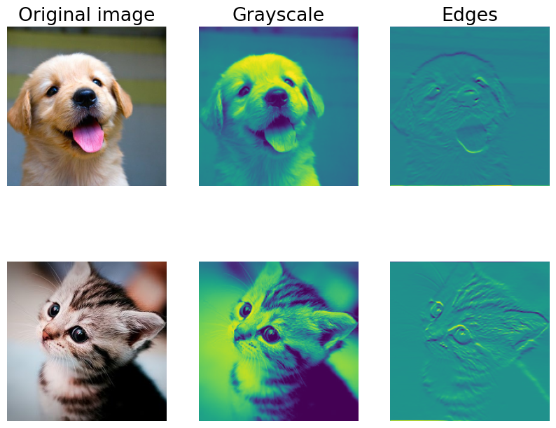

```python
from imageio import imread
from PIL import Image
from torchvision.transforms import ToTensor

kitten_path = os.path.join('kitten.jpeg')
puppy_path = os.path.join('puppy.jpeg')

kitten = imread(kitten_path)
puppy = imread(puppy_path)
# kitten is wide, and puppy is already square
d = kitten.shape[1] - kitten.shape[0]
kitten_cropped = kitten[:, d//2:-d//2, :]

img_size = 200   # Make this smaller if it runs too slow
resized_puppy = ToTensor()(Image.fromarray(puppy).resize((img_size, img_size)))
resized_kitten = ToTensor()(Image.fromarray(kitten_cropped).resize((img_size, img_size)))
x = torch.stack([resized_puppy, resized_kitten])

# Set up a convolutional weights holding 2 filters, each 3x3
w = torch.zeros(2, 3, 3, 3, dtype=x.dtype)

# The first filter converts the image to grayscale.
# Set up the red, green, and blue channels of the filter.
w[0, 0, :, :] = torch.tensor([[0, 0, 0], [0, 0.3, 0], [0, 0, 0]])
w[0, 1, :, :] = torch.tensor([[0, 0, 0], [0, 0.6, 0], [0, 0, 0]])
w[0, 2, :, :] = torch.tensor([[0, 0, 0], [0, 0.1, 0], [0, 0, 0]])

# Second filter detects horizontal edges in the blue channel.
w[1, 2, :, :] = torch.tensor([[1, 2, 1], [0, 0, 0], [-1, -2, -1]])

# Vector of biases. We don't need any bias for the grayscale
# filter, but for the edge detection filter we want to add 128
# to each output so that nothing is negative.
b = torch.tensor([0, 128], dtype=x.dtype)

# Compute the result of convolving each input in x with each filter in w,
# offsetting by b, and storing the results in out.
out, _ = Conv.forward(x, w, b, {'stride': 1, 'pad': 1})

def imshow_no_ax(img, normalize=True):
  """ Tiny helper to show images as uint8 and remove axis labels """
  if normalize:
    img_max, img_min = img.max(), img.min()
    img = 255.0 * (img - img_min) / (img_max - img_min)
  plt.imshow(img)
  plt.gca().axis('off')

# Show the original images and the results of the conv operation
plt.subplot(2, 3, 1)
imshow_no_ax(puppy, normalize=False)
plt.title('Original image')
plt.subplot(2, 3, 2)
imshow_no_ax(out[0, 0])
plt.title('Grayscale')
plt.subplot(2, 3, 3)
imshow_no_ax(out[0, 1])
plt.title('Edges')
plt.subplot(2, 3, 4)
imshow_no_ax(kitten_cropped, normalize=False)
plt.subplot(2, 3, 5)
imshow_no_ax(out[1, 0])
plt.subplot(2, 3, 6)
imshow_no_ax(out[1, 1])
plt.show()
```

## Convolutional layer: backward

Implement the backward pass for the convolution operation in the function `Conv.backward`. Again, you don't need to worry too much about computational efficiency.

After implementing the convolution backward pass, run the following to test your implementation. You should get errors less than `1e-8`.

```python
from convolutional_networks import Conv

reset_seed(0)
x = torch.randn(2, 3, 4, 4, dtype=torch.float64, device='cuda')
w = torch.randn(4, 3, 3, 3, dtype=torch.float64, device='cuda')
b = torch.randn(4, dtype=torch.float64, device='cuda')
dout = torch.randn(2, 4, 4, 4, dtype=torch.float64, device='cuda')
conv_param = {'stride': 1, 'pad': 1}

dx_num = cs639.grad.compute_numeric_gradient(lambda x: Conv.forward(x, w, b, conv_param)[0], x, dout)
dw_num = cs639.grad.compute_numeric_gradient(lambda w: Conv.forward(x, w, b, conv_param)[0], w, dout)
db_num = cs639.grad.compute_numeric_gradient(lambda b: Conv.forward(x, w, b, conv_param)[0], b, dout)

out, cache = Conv.forward(x, w, b, conv_param)
dx, dw, db = Conv.backward(dout, cache)

print('Testing Conv.backward function')
print('dx error: ', cs639.grad.rel_error(dx, dx_num))
print('dw error: ', cs639.grad.rel_error(dw, dw_num))
print('db error: ', cs639.grad.rel_error(db, db_num))
```

```
Testing Conv.backward function
dx error:  1.2549946387608136e-09
dw error:  1.1860571581050883e-09
db error:  7.936417873909316e-10
```

# Max-pooling (10 points)

## Max-pooling: forward

Implement the forward pass for the max-pooling operation. Again, don't worry too much about computational efficiency.

After implementing the forward pass for max-pooling, run the following to check your implementation. You should get errors less than `1e-7`.

```python
from convolutional_networks import MaxPool

reset_seed(0)
x_shape = torch.tensor((1, 3, 6, 6))
x = torch.linspace(-0.4, 0.2, steps=torch.prod(x_shape), dtype=torch.float64, device='cuda').reshape(*x_shape)
pool_param = {'pool_width': 2, 'pool_height': 2, 'stride': 2}

out, _ = MaxPool.forward(x, pool_param)

correct_out = torch.tensor([[[[-0.36074766, -0.34953271, -0.33831776],
                              [-0.29345794, -0.28224299, -0.27102804],
                              [-0.22616822, -0.21495327, -0.20373832]],

                             [[-0.15887850, -0.14766355, -0.13644860],
                              [-0.09158879, -0.08037383, -0.06915888],
                              [-0.02429907, -0.01308411, -0.00186916]],

                             [[ 0.04299065,  0.05420561,  0.06542056],
                              [ 0.11028037,  0.12149533,  0.13271028],
                             [ 0.17757009,  0.18878505,  0.20000000]]]], device='cuda', dtype=torch.float64)
#print (out)
# Compare your output with ours. Difference should be on the order of e-8.
print('Testing MaxPool.forward function:')
print('difference: ', cs639.grad.rel_error(out, correct_out))
```

```
Testing MaxPool.forward function:
difference:  6.865284990610464e-09
```

## Max-pooling: backward

Implement the backward pass for the max-pooling operation. You don't need to worry about computational efficiency.

Check your implementation of the max pooling backward pass with numeric gradient checking by running the following. You should get errors less than `1e-8`.

```python
from convolutional_networks import MaxPool

reset_seed(0)
x = torch.randn(3, 2, 9, 9, dtype=torch.float64, device='cuda')
dout = torch.randn(3, 2, 3, 3, dtype=torch.float64, device='cuda')
pool_param = {'pool_height': 3, 'pool_width': 3, 'stride': 3}

dx_num = cs639.grad.compute_numeric_gradient(lambda x: MaxPool.forward(x, pool_param)[0], x, dout)

out, cache = MaxPool.forward(x, pool_param)
dx = MaxPool.backward(dout, cache)

print('Testing MaxPool.backward function:')
print('dx error: ', cs639.grad.rel_error(dx, dx_num))
```

```
Testing MaxPool.backward function:
dx error:  7.459941346703992e-10
```

# Fast layers

Making convolution and pooling layers fast can be challenging. To spare you the pain, we've provided fast implementations of the forward and backward passes for convolution and pooling layers. Those can be found at the bottom of `convolutional_networks.py`

The fast convolution implementation depends on `torch.nn`

The API for the fast versions of the convolution and pooling layers is exactly the same as the naive versions that you implemented above: the forward pass receives data, weights, and parameters and produces outputs and a cache object; the backward pass recieves upstream derivatives and the cache object and produces gradients with respect to the data and weights.

```
class FastConv(object):

  @staticmethod
  def forward(x, w, b, conv_param):
    N, C, H, W = x.shape
    F, _, HH, WW = w.shape
    stride, pad = conv_param['stride'], conv_param['pad']
    layer = torch.nn.Conv2d(C, F, (HH, WW), stride=stride, padding=pad)
    layer.weight = torch.nn.Parameter(w)
    layer.bias = torch.nn.Parameter(b)
    tx = x.detach()
    tx.requires_grad = True
    out = layer(tx)
    cache = (x, w, b, conv_param, tx, out, layer)
    return out, cache

  @staticmethod
  def backward(dout, cache):
    try:
      x, _, _, _, tx, out, layer = cache
      out.backward(dout)
      dx = tx.grad.detach()
      dw = layer.weight.grad.detach()
      db = layer.bias.grad.detach()
      layer.weight.grad = layer.bias.grad = None
    except RuntimeError:
      dx, dw, db = torch.zeros_like(tx), torch.zeros_like(layer.weight), torch.zeros_like(layer.bias)
    return dx, dw, db


class FastMaxPool(object):

  @staticmethod
  def forward(x, pool_param):
    N, C, H, W = x.shape
    pool_height, pool_width = pool_param['pool_height'], pool_param['pool_width']
    stride = pool_param['stride']
    layer = torch.nn.MaxPool2d(kernel_size=(pool_height, pool_width), stride=stride)
    tx = x.detach()
    tx.requires_grad = True
    out = layer(tx)
    cache = (x, pool_param, tx, out, layer)
    return out, cache

  @staticmethod
  def backward(dout, cache):
    try:
      x, _, tx, out, layer = cache
      out.backward(dout)
      dx = tx.grad.detach()
    except RuntimeError:
      dx = torch.zeros_like(tx)
    return dx
```

We will now compare three different implementations of convolution (both forward and backward):

1. Your naive, non-vectorized implementation on CPU
2. The fast, vectorized implementation on CPU
3. The fast, vectorized implementation on GPU

The differences between your implementation and FastConv should be less than `1e-10`. When moving from your implementation to FastConv CPU, you will likely see speedups of at least 100x. When comparing your implementation to FastConv CUDA, you will likely see speedups of more than 500x. (These speedups are not hard requirements for this assignment since we are not asking you to write any vectorized implementations). Finally, if you are not able to get the desired speedups, try running the cell multiple times.

```python
# Rel errors should be around e-11 or less
from convolutional_networks import Conv, FastConv

reset_seed(0)
x = torch.randn(50, 3, 20, 20, dtype=torch.float64, device='cuda')
w = torch.randn(10, 3, 3, 3, dtype=torch.float64, device='cuda')
b = torch.randn(10, dtype=torch.float64, device='cuda')
dout = torch.randn(50, 10, 10, 10, dtype=torch.float64, device='cuda')
x_cuda, w_cuda, b_cuda, dout_cuda = x.to('cuda'), w.to('cuda'), b.to('cuda'), dout.to('cuda')
conv_param = {'stride': 2, 'pad': 1}

t0 = time.time()
out_naive, cache_naive = Conv.forward(x, w, b, conv_param)
t1 = time.time()
out_fast, cache_fast = FastConv.forward(x, w, b, conv_param)
t2 = time.time()
out_fast_cuda, cache_fast_cuda = FastConv.forward(x_cuda, w_cuda, b_cuda, conv_param)
t3 = time.time()

print('Testing FastConv.forward:')
print('Naive: %fs' % (t1 - t0))
print('Fast: %fs' % (t2 - t1))
print('Fast CUDA: %fs' % (t3 - t2))
print('Speedup: %fx' % ((t1 - t0) / (t2 - t1)))
print('Speedup CUDA: %fx' % ((t1 - t0) / (t3 - t2)))
print('Difference: ', cs639.grad.rel_error(out_naive, out_fast))
print('Difference CUDA: ', cs639.grad.rel_error(out_naive, out_fast_cuda.to(out_naive.device)))

t0 = time.time()
dx_naive, dw_naive, db_naive = Conv.backward(dout, cache_naive)
t1 = time.time()
dx_fast, dw_fast, db_fast = FastConv.backward(dout, cache_fast)
t2 = time.time()
dx_fast_cuda, dw_fast_cuda, db_fast_cuda = FastConv.backward(dout_cuda, cache_fast_cuda)
t3 = time.time()

print('\nTesting FastConv.backward:')
print('Naive: %fs' % (t1 - t0))
print('Fast: %fs' % (t2 - t1))
print('Fast CUDA: %fs' % (t3 - t2))
print('Speedup: %fx' % ((t1 - t0) / (t2 - t1)))
print('Speedup CUDA: %fx' % ((t1 - t0) / (t3 - t2)))
print('dx difference: ', cs639.grad.rel_error(dx_naive, dx_fast))
print('dw difference: ', cs639.grad.rel_error(dw_naive, dw_fast))
print('db difference: ', cs639.grad.rel_error(db_naive, db_fast))
print('dx difference CUDA: ', cs639.grad.rel_error(dx_naive, dx_fast_cuda.to(dx_naive.device)))
print('dw difference CUDA: ', cs639.grad.rel_error(dw_naive, dw_fast_cuda.to(dw_naive.device)))
print('db difference CUDA: ', cs639.grad.rel_error(db_naive, db_fast_cuda.to(db_naive.device)))
```

```
Testing FastConv.forward:
Naive: 1.734779s
Fast: 0.114060s
Fast CUDA: 0.000455s
Speedup: 15.209395x
Speedup CUDA: 3813.516771x
Difference:  2.1006400935383913e-16
Difference CUDA:  2.1006400935383913e-16

Testing FastConv.backward:
Naive: 3.178397s
Fast: 0.034144s
Fast CUDA: 0.000443s
Speedup: 93.087563x
Speedup CUDA: 7175.006997x
dx difference:  2.258316625160561e-16
dw difference:  1.7856837664934115e-15
db difference:  1.2172795254706628e-15
dx difference CUDA:  2.2583166251605614e-16
dw difference CUDA:  1.6071153898440702e-15
db difference CUDA:  1.2172795254706628e-15
```

We will now similarly compare your naive implementation of max pooling against the fast implementation. You should see differences of 0 between your implementation and the fast implementation.

When comparing your implementation against FastMaxPool on CPU, you will likely see speedups of more than 100x. When comparing your implementation against FastMaxPool on GPU, you will likely see speedups of more than 500x.

```python
# Relative errors should be close to 0.0
from convolutional_networks import Conv, MaxPool, FastConv, FastMaxPool


reset_seed(0)
x = torch.randn(40, 3, 24, 24, dtype=torch.float64, device='cuda')
dout = torch.randn(40, 3, 12, 12, dtype=torch.float64, device='cuda')
x_cuda, dout_cuda = x.to('cuda'), dout.to('cuda')
pool_param = {'pool_height': 2, 'pool_width': 2, 'stride': 2}

t0 = time.time()
out_naive, cache_naive = MaxPool.forward(x, pool_param)
t1 = time.time()
out_fast, cache_fast = FastMaxPool.forward(x, pool_param)
t2 = time.time()
out_fast_cuda, cache_fast_cuda = FastMaxPool.forward(x_cuda, pool_param)
t3 = time.time()

print('Testing FastMaxPool.forward:')
print('Naive: %fs' % (t1 - t0))
print('Fast: %fs' % (t2 - t1))
print('Fast CUDA: %fs' % (t3 - t2))
print('Speedup: %fx' % ((t1 - t0) / (t2 - t1)))
print('Speedup CUDA: %fx' % ((t1 - t0) / (t3 - t2)))
print('Difference: ', cs639.grad.rel_error(out_naive, out_fast))
print('Difference CUDA: ', cs639.grad.rel_error(out_naive, out_fast_cuda.to(out_naive.device)))

t0 = time.time()
dx_naive = MaxPool.backward(dout, cache_naive)
t1 = time.time()
dx_fast = FastMaxPool.backward(dout, cache_fast)
t2 = time.time()
dx_fast_cuda = FastMaxPool.backward(dout_cuda, cache_fast_cuda)
t3 = time.time()

print('\nTesting FastMaxPool.backward:')
print('Naive: %fs' % (t1 - t0))
print('Fast: %fs' % (t2 - t1))
print('Fast CUDA: %fs' % (t3 - t2))
print('Speedup: %fx' % ((t1 - t0) / (t2 - t1)))
print('Speedup CUDA: %fx' % ((t1 - t0) / (t3 - t2)))
print('dx difference: ', cs639.grad.rel_error(dx_naive, dx_fast))
print('dx difference CUDA: ', cs639.grad.rel_error(dx_naive, dx_fast_cuda.to(dx_naive.device)))
```

```
Testing FastMaxPool.forward:
Naive: 0.400903s
Fast: 0.012057s
Fast CUDA: 0.000173s
Speedup: 33.251157x
Speedup CUDA: 2312.944979x
Difference:  0.0
Difference CUDA:  0.0

Testing FastMaxPool.backward:
Naive: 0.730496s
Fast: 0.000390s
Fast CUDA: 0.000111s
Speedup: 1873.957798x
Speedup CUDA: 6560.858672x
dx difference:  0.0
dx difference CUDA:  0.0
```

# Convolutional "sandwich" layers

Previously we introduced the concept of "sandwich" layers that combine multiple operations into commonly used patterns. Below you will find sandwich layers that implement a few commonly used patterns for convolutional networks. We've included them at the bottom of `covolutional_networks.py` Run the cells below to sanity check they're working.

```
class Conv_ReLU(object):

  @staticmethod
  def forward(x, w, b, conv_param):
    """
    A convenience layer that performs a convolution followed by a ReLU.
    Inputs:
    - x: Input to the convolutional layer
    - w, b, conv_param: Weights and parameters for the convolutional layer
    Returns a tuple of:
    - out: Output from the ReLU
    - cache: Object to give to the backward pass
    """
    a, conv_cache = FastConv.forward(x, w, b, conv_param)
    out, relu_cache = ReLU.forward(a)
    cache = (conv_cache, relu_cache)
    return out, cache

  @staticmethod
  def backward(dout, cache):
    """
    Backward pass for the conv-relu convenience layer.
    """
    conv_cache, relu_cache = cache
    da = ReLU.backward(dout, relu_cache)
    dx, dw, db = FastConv.backward(da, conv_cache)
    return dx, dw, db


class Conv_ReLU_Pool(object):

  @staticmethod
  def forward(x, w, b, conv_param, pool_param):
    """
    A convenience layer that performs a convolution, a ReLU, and a pool.
    Inputs:
    - x: Input to the convolutional layer
    - w, b, conv_param: Weights and parameters for the convolutional layer
    - pool_param: Parameters for the pooling layer
    Returns a tuple of:
    - out: Output from the pooling layer
    - cache: Object to give to the backward pass
    """
    a, conv_cache = FastConv.forward(x, w, b, conv_param)
    s, relu_cache = ReLU.forward(a)
    out, pool_cache = FastMaxPool.forward(s, pool_param)
    cache = (conv_cache, relu_cache, pool_cache)
    return out, cache

  @staticmethod
  def backward(dout, cache):
    """
    Backward pass for the conv-relu-pool convenience layer
    """
    conv_cache, relu_cache, pool_cache = cache
    ds = FastMaxPool.backward(dout, pool_cache)
    da = ReLU.backward(ds, relu_cache)
    dx, dw, db = FastConv.backward(da, conv_cache)
    return dx, dw, db
```

Test the implementations of the sandwich layers by running the following. You should see errors less than `1e-7`.

```python
from convolutional_networks import Conv_ReLU, Conv_ReLU_Pool
reset_seed(0)

# Test Conv ReLU
x = torch.randn(5, 3, 6, 6, dtype=torch.float64, device='cuda')
w = torch.randn(3, 3, 3, 3, dtype=torch.float64, device='cuda')
b = torch.randn(3, dtype=torch.float64, device='cuda')
dout = torch.randn(5, 3, 6, 6, dtype=torch.float64, device='cuda')
conv_param = {'stride': 1, 'pad': 1}

out, cache = Conv_ReLU.forward(x, w, b, conv_param)
dx, dw, db = Conv_ReLU.backward(dout, cache)

dx_num = cs639.grad.compute_numeric_gradient(lambda x: Conv_ReLU.forward(x, w, b, conv_param)[0], x, dout)
dw_num = cs639.grad.compute_numeric_gradient(lambda w: Conv_ReLU.forward(x, w, b, conv_param)[0], w, dout)
db_num = cs639.grad.compute_numeric_gradient(lambda b: Conv_ReLU.forward(x, w, b, conv_param)[0], b, dout)

# Relative errors should be around e-8 or less
print('Testing Conv_ReLU:')
print('dx error: ', cs639.grad.rel_error(dx_num, dx))
print('dw error: ', cs639.grad.rel_error(dw_num, dw))
print('db error: ', cs639.grad.rel_error(db_num, db))

# Test Conv ReLU Pool
x = torch.randn(5, 3, 24, 24, dtype=torch.float64, device='cuda')
w = torch.randn(3, 3, 3, 3, dtype=torch.float64, device='cuda')
b = torch.randn(3, dtype=torch.float64, device='cuda')
dout = torch.randn(5, 3, 8, 8, dtype=torch.float64, device='cuda')
conv_param = {'stride': 1, 'pad': 1}
pool_param = {'pool_height': 3, 'pool_width': 3, 'stride': 3}

out, cache = Conv_ReLU_Pool.forward(x, w, b, conv_param, pool_param)
dx, dw, db = Conv_ReLU_Pool.backward(dout, cache)

dx_num = cs639.grad.compute_numeric_gradient(lambda x: Conv_ReLU_Pool.forward(x, w, b, conv_param, pool_param)[0], x, dout)
dw_num = cs639.grad.compute_numeric_gradient(lambda w: Conv_ReLU_Pool.forward(x, w, b, conv_param, pool_param)[0], w, dout)
db_num = cs639.grad.compute_numeric_gradient(lambda b: Conv_ReLU_Pool.forward(x, w, b, conv_param, pool_param)[0], b, dout)

# Relative errors should be around e-8 or less
print()
print('Testing Conv_ReLU_Pool')
print('dx error: ', cs639.grad.rel_error(dx_num, dx))
print('dw error: ', cs639.grad.rel_error(dw_num, dw))
print('db error: ', cs639.grad.rel_error(db_num, db))
```

```
Testing Conv_ReLU:
dx error:  1.588946377276612e-09
dw error:  1.1055148646913608e-09
db error:  5.774053829106511e-10

Testing Conv_ReLU_Pool
dx error:  1.8217126985783583e-09
dw error:  1.4995875614621324e-09
db error:  1.3713497873139854e-09
```

# Three-layer convolutional network (18 points)

Now that you have implemented all the necessary layers, we can put them together into a simple convolutional network.

Complete the implementation of the `ThreeLayerConvNet` class. We STRONGLY recommend you to use the fast/sandwich layers (already imported for you) in your implementation. Run the following cells to help you debug:

## Sanity check loss

After you build a new network, one of the first things you should do is sanity check the loss. When we use the softmax loss, we expect the loss for random weights (and no regularization) to be about `log(C)` for `C` classes. When we add regularization the loss should go up slightly.

```python
from convolutional_networks import ThreeLayerConvNet

reset_seed(0)
model = ThreeLayerConvNet(dtype=torch.float64, device='cuda')

N = 20
X = torch.randn(N, 3, 32, 32, dtype=torch.float64, device='cuda')
y = torch.randint(10, size=(N,), dtype=torch.int64, device='cuda')

loss, grads = model.loss(X, y)
print('Initial loss (no regularization): ', loss.item())

model.reg = 0.3
loss, grads = model.loss(X, y)
print('Initial loss (with regularization): ', loss.item())
```

```
Initial loss (no regularization):  2.302588003887487
Initial loss (with regularization):  2.550307834380315
```

## Gradient check

After the loss looks reasonable, use numeric gradient checking to make sure that your backward pass is correct. When you use numeric gradient checking you should use a small amount of artificial data and a small number of neurons at each layer.

You should see errors less than `1e-5`.

```python
from convolutional_networks import ThreeLayerConvNet

num_inputs = 2
input_dims = (3, 16, 16)
reg = 0.0
num_classes = 10
reset_seed(0)
X = torch.randn(num_inputs, *input_dims, dtype=torch.float64, device='cuda')
y = torch.randint(num_classes, size=(num_inputs,), dtype=torch.int64, device='cuda')

model = ThreeLayerConvNet(num_filters=3, filter_size=3,
                          input_dims=input_dims, hidden_dim=7,
                          weight_scale=5e-2, dtype=torch.float64, device='cuda')
loss, grads = model.loss(X, y)

for param_name in sorted(grads):
    f = lambda _: model.loss(X, y)[0]
    param_grad_num = cs639.grad.compute_numeric_gradient(f, model.params[param_name])
    print('%s max relative error: %e' % (param_name, cs639.grad.rel_error(param_grad_num, grads[param_name])))
```

```
W1 max relative error: 2.851376e-08
W2 max relative error: 7.622434e-08
W3 max relative error: 5.229266e-09
b1 max relative error: 1.252231e-08
b2 max relative error: 2.934901e-08
b3 max relative error: 3.205744e-09
```

## Overfit small data

A nice trick is to train your model with just a few training samples. You should be able to overfit small datasets, which will result in very high training accuracy and comparatively low validation accuracy.

```python
from convolutional_networks import ThreeLayerConvNet
from fully_connected_networks import adam, sgd_momentum

reset_seed(0)

num_train = 50
small_data = {
  'X_train': data_dict['X_train'][:num_train],
  'y_train': data_dict['y_train'][:num_train],
  'X_val': data_dict['X_val'],
  'y_val': data_dict['y_val'],
}

model = ThreeLayerConvNet(weight_scale=1e-3, dtype=torch.float32, device='cuda')

solver = Solver(model, small_data,
                num_epochs=20, batch_size=100,
                update_rule=adam,
                optim_config={
                  'learning_rate': 5e-3,
                },
                verbose=True, print_every=1,
                device='cuda')
solver.train()
```

```
(Time 0.18 sec; Iteration 1 / 20) loss: 2.302585
(Epoch 1 / 20) train acc: 0.160000; val_acc: 0.101600
(Time 0.24 sec; Iteration 2 / 20) loss: 2.266708
(Epoch 2 / 20) train acc: 0.160000; val_acc: 0.101600
(Time 0.28 sec; Iteration 3 / 20) loss: 2.249194
(Epoch 3 / 20) train acc: 0.280000; val_acc: 0.148900
(Time 0.33 sec; Iteration 4 / 20) loss: 2.128586
(Epoch 4 / 20) train acc: 0.320000; val_acc: 0.158000
(Time 0.38 sec; Iteration 5 / 20) loss: 2.065211
(Epoch 5 / 20) train acc: 0.340000; val_acc: 0.171700
(Time 0.42 sec; Iteration 6 / 20) loss: 1.916057
(Epoch 6 / 20) train acc: 0.340000; val_acc: 0.163500
(Time 0.46 sec; Iteration 7 / 20) loss: 1.753283
(Epoch 7 / 20) train acc: 0.420000; val_acc: 0.166300
(Time 0.50 sec; Iteration 8 / 20) loss: 1.577718
(Epoch 8 / 20) train acc: 0.500000; val_acc: 0.182100
(Time 0.53 sec; Iteration 9 / 20) loss: 1.402187
(Epoch 9 / 20) train acc: 0.600000; val_acc: 0.186300
(Time 0.57 sec; Iteration 10 / 20) loss: 1.203068
(Epoch 10 / 20) train acc: 0.660000; val_acc: 0.189700
(Time 0.61 sec; Iteration 11 / 20) loss: 1.010733
(Epoch 11 / 20) train acc: 0.720000; val_acc: 0.194300
(Time 0.64 sec; Iteration 12 / 20) loss: 0.809603
(Epoch 12 / 20) train acc: 0.860000; val_acc: 0.192000
(Time 0.68 sec; Iteration 13 / 20) loss: 0.611783
(Epoch 13 / 20) train acc: 0.880000; val_acc: 0.187000
(Time 0.72 sec; Iteration 14 / 20) loss: 0.430627
(Epoch 14 / 20) train acc: 0.940000; val_acc: 0.186500
(Time 0.76 sec; Iteration 15 / 20) loss: 0.284393
(Epoch 15 / 20) train acc: 0.940000; val_acc: 0.191000
(Time 0.79 sec; Iteration 16 / 20) loss: 0.195423
(Epoch 16 / 20) train acc: 0.980000; val_acc: 0.189000
(Time 0.83 sec; Iteration 17 / 20) loss: 0.122585
(Epoch 17 / 20) train acc: 0.960000; val_acc: 0.189900
(Time 0.87 sec; Iteration 18 / 20) loss: 0.128115
(Epoch 18 / 20) train acc: 0.980000; val_acc: 0.184000
(Time 0.90 sec; Iteration 19 / 20) loss: 0.049736
(Epoch 19 / 20) train acc: 0.980000; val_acc: 0.189300
(Time 0.94 sec; Iteration 20 / 20) loss: 0.028904
(Epoch 20 / 20) train acc: 1.000000; val_acc: 0.199400
```

Plotting the loss, training accuracy, and validation accuracy should show clear overfitting:

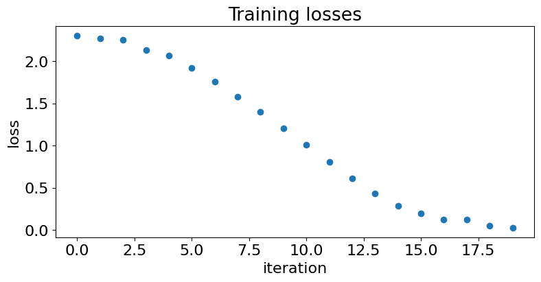

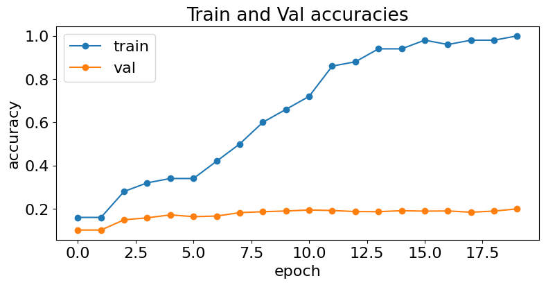

```python
plt.title('Training losses')
plt.plot(solver.loss_history, 'o')
plt.xlabel('iteration')
plt.ylabel('loss')
plt.gcf().set_size_inches(9, 4)
plt.show()

plt.title('Train and Val accuracies')
plt.plot(solver.train_acc_history, '-o')
plt.plot(solver.val_acc_history, '-o')
plt.legend(['train', 'val'], loc='upper left')
plt.xlabel('epoch')
plt.ylabel('accuracy')
plt.gcf().set_size_inches(9, 4)
plt.show()
```

## Train the net

By training the three-layer convolutional network for one epoch, you should achieve greater than 50% accuracy on the training set:

```python
from convolutional_networks import ThreeLayerConvNet
from fully_connected_networks import adam

reset_seed(0)

model = ThreeLayerConvNet(weight_scale=0.001, hidden_dim=200, reg=0.001, dtype=torch.float, device='cuda')

solver = Solver(model, data_dict,
                num_epochs=1, batch_size=100,
                update_rule=adam,
                optim_config={
                  'learning_rate': 5e-3,
                },
                verbose=True, print_every=50, device='cuda')
solver.train()
```

```
(Time 0.01 sec; Iteration 1 / 400) loss: 2.304229
(Epoch 0 / 1) train acc: 0.102000; val_acc: 0.102500
(Time 0.24 sec; Iteration 51 / 400) loss: 2.310990
(Time 0.40 sec; Iteration 101 / 400) loss: 2.192547
(Time 0.56 sec; Iteration 151 / 400) loss: 1.895574
(Time 0.72 sec; Iteration 201 / 400) loss: 1.939390
(Time 0.88 sec; Iteration 251 / 400) loss: 1.832893
(Time 1.05 sec; Iteration 301 / 400) loss: 1.940857
(Time 1.22 sec; Iteration 351 / 400) loss: 1.587473
(Epoch 1 / 1) train acc: 0.565000; val_acc: 0.533800
```

## Visualize Filters

You can visualize the first-layer convolutional filters from the trained network by running the following:

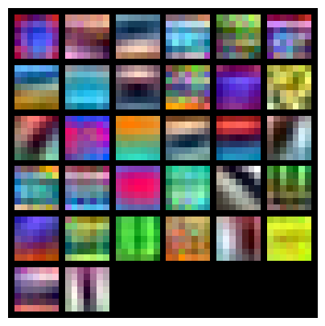

```python
from torchvision.utils import make_grid
nrow = math.ceil(math.sqrt(model.params['W1'].shape[0]))
grid = make_grid(model.params['W1'], nrow=nrow, padding=1, normalize=True, scale_each=True)
plt.imshow(grid.to(device='cpu').permute(1, 2, 0))
plt.axis('off')
plt.gcf().set_size_inches(5, 5)
plt.show()
```

# Deep convolutional network (15 points)

Next you will implement a deep convolutional network with an arbitrary number of conv layers in VGGNet style.

Read through the `DeepConvNet` class.

Implement the initialization, the forward pass, and the backward pass. For the moment don't worry about implementing batch normalization; we will add those features soon. Again, we STRONGLY recommend you to use the fast/sandwich layers (already imported for you) in your implementation.

## Sanity check loss

After you build a new network, one of the first things you should do is sanity check the loss. When we use the softmax loss, we expect the loss for random weights (and no regularization) to be about `log(C)` for `C` classes. When we add regularization the loss should go up slightly.

```python
from convolutional_networks import DeepConvNet
from fully_connected_networks import adam

reset_seed(0)
input_dims = (3, 32, 32)
model = DeepConvNet(num_filters=[8, 64], max_pools=[0, 1], dtype=torch.float64, device='cuda')

N = 50
X = torch.randn(N, *input_dims, dtype=torch.float64, device='cuda')
y = torch.randint(10, size=(N,), dtype=torch.int64, device='cuda')

loss, grads = model.loss(X, y)
print('Initial loss (no regularization): ', loss.item())

model.reg = 1.5
loss, grads = model.loss(X, y)
print('Initial loss (with regularization): ', loss.item())
```

```
Initial loss (no regularization):  2.302585347591701
Initial loss (with regularization):  2.3710349671319895
```

## Gradient check

After the loss looks reasonable, use numeric gradient checking to make sure that your backward pass is correct. When you use numeric gradient checking you should use a small amount of artifical data and a small number of neurons at each layer.

You should see relative errors less than `1e-5`.

```python
from convolutional_networks import DeepConvNet
from fully_connected_networks import adam

reset_seed(0)
num_inputs = 5
input_dims = (3, 8, 8)
num_classes = 10
X = torch.randn(N, *input_dims, dtype=torch.float64, device='cuda')
y = torch.randint(10, size=(N,), dtype=torch.int64, device='cuda')

for reg in [0, 3.14]:
  print('Running check with reg = ', reg)
  model = DeepConvNet(input_dims=input_dims, num_classes=num_classes,
                      num_filters=[8, 8, 8],
                      max_pools=[0, 2],
                      reg=reg,
                      weight_scale=5e-2, dtype=torch.float64, device='cuda')

  loss, grads = model.loss(X, y)
  # The relative errors should be up to the order of e-6
  for name in sorted(grads):
    f = lambda _: model.loss(X, y)[0]
    grad_num = cs639.grad.compute_numeric_gradient(f, model.params[name])
    print('%s max relative error: %e' % (name, cs639.grad.rel_error(grad_num, grads[name])))
  if reg == 0: print()
```

```
Running check with reg =  0
W1 max relative error: 5.912415e-07
W2 max relative error: 8.190183e-07
W3 max relative error: 5.317616e-07
W4 max relative error: 6.344352e-07
b1 max relative error: 6.956690e-07
b2 max relative error: 4.282076e-07
b3 max relative error: 2.831506e-08
b4 max relative error: 1.407349e-08

Running check with reg =  3.14
W1 max relative error: 7.242144e-09
W2 max relative error: 1.032423e-08
W3 max relative error: 1.289720e-08
W4 max relative error: 7.251152e-09
b1 max relative error: 1.994212e-06
b2 max relative error: 1.289978e-06
b3 max relative error: 4.524272e-07
b4 max relative error: 9.903249e-08
```

## Overfit small data

As another sanity check, make sure you can overfit a small dataset of 100 images. In the following cell, tweak the **learning rate** and **weight initialization scale** to overfit and achieve close to 100% training accuracy within 20 epochs.

```
(Time 0.06 sec; Iteration 1 / 200) loss: 2.382387
(Epoch 0 / 20) train acc: 0.070000; val_acc: 0.099800
(Epoch 1 / 20) train acc: 0.130000; val_acc: 0.102700
(Time 0.35 sec; Iteration 11 / 200) loss: 2.280317
(Epoch 2 / 20) train acc: 0.320000; val_acc: 0.109900
(Time 0.51 sec; Iteration 21 / 200) loss: 2.296071
(Epoch 3 / 20) train acc: 0.230000; val_acc: 0.097100
(Time 0.67 sec; Iteration 31 / 200) loss: 1.912371
(Epoch 4 / 20) train acc: 0.280000; val_acc: 0.107100
(Time 0.82 sec; Iteration 41 / 200) loss: 2.197158
(Epoch 5 / 20) train acc: 0.470000; val_acc: 0.164300
(Time 0.97 sec; Iteration 51 / 200) loss: 1.749131
(Epoch 6 / 20) train acc: 0.500000; val_acc: 0.169900
(Time 1.12 sec; Iteration 61 / 200) loss: 1.414135
(Epoch 7 / 20) train acc: 0.550000; val_acc: 0.188100
(Time 1.27 sec; Iteration 71 / 200) loss: 0.607335
(Epoch 8 / 20) train acc: 0.650000; val_acc: 0.195100
(Time 1.42 sec; Iteration 81 / 200) loss: 1.707597
(Epoch 9 / 20) train acc: 0.740000; val_acc: 0.173400
(Time 1.58 sec; Iteration 91 / 200) loss: 0.969943
(Epoch 10 / 20) train acc: 0.800000; val_acc: 0.211600
(Time 1.73 sec; Iteration 101 / 200) loss: 0.816052
(Epoch 11 / 20) train acc: 0.880000; val_acc: 0.208800
(Time 1.89 sec; Iteration 111 / 200) loss: 0.276536
(Epoch 12 / 20) train acc: 0.940000; val_acc: 0.222800
(Time 2.04 sec; Iteration 121 / 200) loss: 0.389858
(Epoch 13 / 20) train acc: 0.910000; val_acc: 0.223000
(Time 2.20 sec; Iteration 131 / 200) loss: 0.326893
(Epoch 14 / 20) train acc: 0.970000; val_acc: 0.234500
(Time 2.35 sec; Iteration 141 / 200) loss: 0.058817
(Epoch 15 / 20) train acc: 0.980000; val_acc: 0.203000
(Time 2.50 sec; Iteration 151 / 200) loss: 0.421944
(Epoch 16 / 20) train acc: 1.000000; val_acc: 0.232200
(Time 2.65 sec; Iteration 161 / 200) loss: 0.073631
(Epoch 17 / 20) train acc: 1.000000; val_acc: 0.223300
(Time 2.81 sec; Iteration 171 / 200) loss: 0.058046
(Epoch 18 / 20) train acc: 1.000000; val_acc: 0.234000
(Time 2.96 sec; Iteration 181 / 200) loss: 0.043342
(Epoch 19 / 20) train acc: 1.000000; val_acc: 0.228400
(Time 3.12 sec; Iteration 191 / 200) loss: 0.013928
(Epoch 20 / 20) train acc: 1.000000; val_acc: 0.239500
```

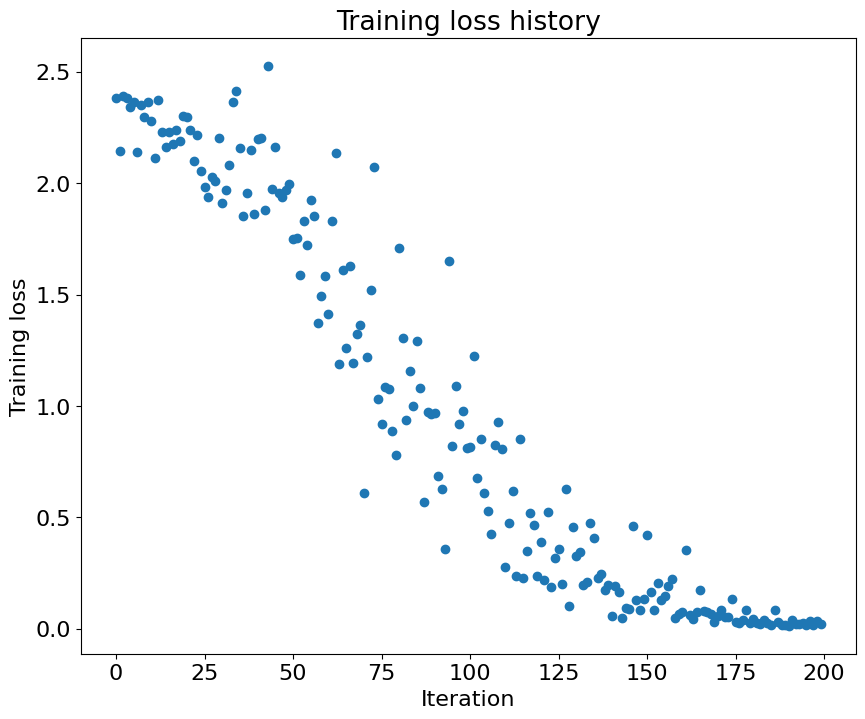

```
1.0
```

```python
# TODO: Use a DeepConvNet to overfit 100 training examples by
# tweaking just the learning rate and initialization scale.
from convolutional_networks import DeepConvNet, find_overfit_parameters
from fully_connected_networks import adam

reset_seed(0)
num_train = 100
small_data = {
  'X_train': data_dict['X_train'][:num_train],
  'y_train': data_dict['y_train'][:num_train],
  'X_val': data_dict['X_val'],
  'y_val': data_dict['y_val'],
}
input_dims = small_data['X_train'].shape[1:]


# Update the parameters in find_overfit_parameters in convolutional_networks.py
weight_scale, learning_rate = find_overfit_parameters()


model = DeepConvNet(input_dims=input_dims, num_classes=10,
                    num_filters=[4, 16, 64, 128],
                    max_pools=[0, 1, 2, 3],
                    reg=1e-5, weight_scale=weight_scale, dtype=torch.float32, device='cuda')
solver = Solver(model, small_data,
                print_every=10, num_epochs=20, batch_size=10,
                update_rule=adam,
                optim_config={
                  'learning_rate': learning_rate,
                },
                device='cuda',
         )
# Turn off keep_best_params to allow final weights to be saved, instead of best weights on validation set.
solver.train(return_best_params=False)

plt.plot(solver.loss_history, 'o')
plt.title('Training loss history')
plt.xlabel('Iteration')
plt.ylabel('Training loss')
plt.show()

val_acc = solver.check_accuracy(
                        solver.X_train, solver.y_train, num_samples=solver.num_train_samples
                    )
print(val_acc)
```

If you're happy with the model's perfromance, run the following cell to save it.

We will also reload the model and run it on the training data to verify it's the right weights.

```python
path = os.path.join('overfit_deepconvnet.pth')
solver.model.save(path)

# Create a new instance
model = DeepConvNet(input_dims=input_dims, num_classes=10,
                    num_filters=[4, 16, 64, 128],
                    max_pools=[0, 1, 2, 3],
                    reg=1e-5, weight_scale=weight_scale, dtype=torch.float32, device='cuda')
solver = Solver(model, small_data,
                print_every=10, num_epochs=30, batch_size=10,
                update_rule=adam,
                optim_config={
                  'learning_rate': learning_rate,
                },
                device='cuda',
         )


# Load model
solver.model.load(path, dtype=torch.float32, device='cuda')

# Evaluate on validation set
accuracy = solver.check_accuracy(small_data['X_train'], small_data['y_train'])
print(f"Saved model's accuracy on training is {accuracy}")
```

```
Saved in overfit_deepconvnet.pth
load checkpoint file: overfit_deepconvnet.pth
Saved model's accuracy on training is 1.0
```

# Kaiming initialization (8 points)

So far, you manually tuned the weight scale and for weight initialization. However, this is inefficient when it comes to training deep neural networks; practically, as your weight matrix is larger, the weight scale should be small. Below you will implement [Kaiming initialization](http://arxiv-web3.library.cornell.edu/abs/1502.01852). For more details, refer to [cs231n note](http://cs231n.github.io/neural-networks-2/#init) and [PyTorch documentation](https://pytorch.org/docs/stable/nn.init.html#torch.nn.init.kaiming_normal_).

# Convolutional nets with Kaiming initialization

Now that you have a working implementation for Kaiming initialization, go back to your `DeepConvnet`. Modify your implementation to add Kaiming initialization.

Concretely, when the `weight_scale` is set to `'kaiming'` in the constructor, you should initialize weights of convolutional and linear layers using `kaiming_initializer`. Once you are done, run the following to see the effect of kaiming initialization in deep CNNs.

In this experiment, we train a 31-layer network with four different weight initialization schemes. The only expectation at this point is that `'kaiming'` should not return `nan` loss. However, you will be using Kaiming initialization in later parts of the assignment.

You may see `nan` loss when `weight_scale` is large, this shows a catastrophe of inappropriate weight initialization.

```python
from convolutional_networks import DeepConvNet
from fully_connected_networks import sgd_momentum
reset_seed(0)

# Try training a deep convolutional net with different weight initialization methods
num_train = 10000
small_data = {
  'X_train': data_dict['X_train'][:num_train],
  'y_train': data_dict['y_train'][:num_train],
  'X_val': data_dict['X_val'],
  'y_val': data_dict['y_val'],
}
input_dims = data_dict['X_train'].shape[1:]

weight_scales = ['kaiming', 1e-1, 1e-2, 1e-3]

solvers = []
for weight_scale in weight_scales:
  print('Solver with weight scale: ', weight_scale)
  model = DeepConvNet(input_dims=input_dims, num_classes=10,
                      num_filters=([8] * 10) + ([32] * 10) + ([128] * 10),
                      max_pools=[9, 19],
                      weight_scale=weight_scale,
                      reg=1e-5,
                      dtype=torch.float32,
                      device='cuda'
                      )

  solver = Solver(model, small_data,
                  num_epochs=1, batch_size=128,
                  update_rule=sgd_momentum,
                  optim_config={
                    'learning_rate': 2e-3,
                  },
                  print_every=20, device='cuda')
  solver.train()
  solvers.append(solver)
```

```
Solver with weight scale:  kaiming
(Time 0.04 sec; Iteration 1 / 78) loss: 2.346567
(Epoch 0 / 1) train acc: 0.111000; val_acc: 0.104100
(Time 1.65 sec; Iteration 21 / 78) loss: 2.323823
(Time 2.12 sec; Iteration 41 / 78) loss: 2.251589
(Time 2.58 sec; Iteration 61 / 78) loss: 2.159546
(Epoch 1 / 1) train acc: 0.229000; val_acc: 0.244800
Solver with weight scale:  0.1
(Time 0.02 sec; Iteration 1 / 78) loss: 78.595032
(Epoch 0 / 1) train acc: 0.113000; val_acc: 0.095200
(Time 1.63 sec; Iteration 21 / 78) loss: nan
(Time 2.08 sec; Iteration 41 / 78) loss: nan
(Time 2.55 sec; Iteration 61 / 78) loss: nan
(Epoch 1 / 1) train acc: 0.092000; val_acc: 0.101400
Solver with weight scale:  0.01
(Time 0.02 sec; Iteration 1 / 78) loss: 2.304121
(Epoch 0 / 1) train acc: 0.120000; val_acc: 0.100300
(Time 1.62 sec; Iteration 21 / 78) loss: 2.304192
(Time 2.07 sec; Iteration 41 / 78) loss: 2.303957
(Time 2.53 sec; Iteration 61 / 78) loss: 2.303829
(Epoch 1 / 1) train acc: 0.111000; val_acc: 0.100300
Solver with weight scale:  0.001
(Time 0.02 sec; Iteration 1 / 78) loss: 2.302599
(Epoch 0 / 1) train acc: 0.095000; val_acc: 0.098000
(Time 1.65 sec; Iteration 21 / 78) loss: 2.302582
(Time 2.10 sec; Iteration 41 / 78) loss: 2.302864
(Time 2.57 sec; Iteration 61 / 78) loss: 2.302748
(Epoch 1 / 1) train acc: 0.094000; val_acc: 0.098000
```

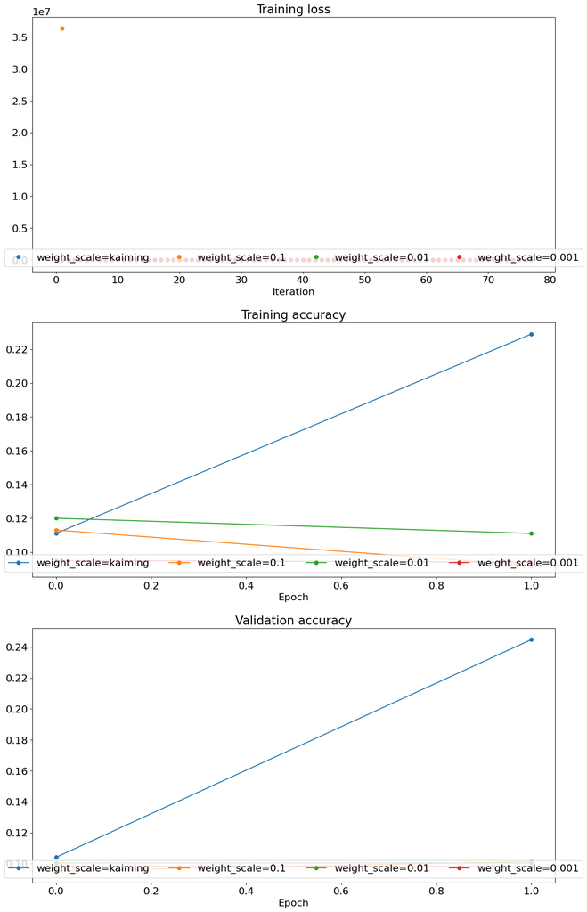

```python
def plot_training_history_init(title, xlabel, solvers, labels, plot_fn, marker='-o'):
  plt.title(title)
  plt.xlabel(xlabel)
  for solver, label in zip(solvers, labels):
    data = plot_fn(solver)
    label = 'weight_scale=' + str(label)
    plt.plot(data, marker, label=label)
  plt.legend(loc='lower center', ncol=len(solvers))

plt.subplot(3, 1, 1)
plot_training_history_init('Training loss','Iteration', solvers, weight_scales,
                            lambda x: x.loss_history, marker='o')
plt.subplot(3, 1, 2)
plot_training_history_init('Training accuracy','Epoch', solvers, weight_scales,
                           lambda x: x.train_acc_history)
plt.subplot(3, 1, 3)
plot_training_history_init('Validation accuracy','Epoch', solvers, weight_scales,
                           lambda x: x.val_acc_history)
plt.gcf().set_size_inches(15, 25)
plt.show()
```

# Train a good model!

Train the best convolutional model that you can on CIFAR-10, storing your best model in the `best_model` variable. We require you to get at least 67% accuracy on the validation set using a convolutional net, within 60 seconds of training.

You might find it useful to use batch normalization in your model. However, since we do not ask you to implement it CUDA-friendly, it might slow down training.

**Implement** `create_convolutional_solver_instance` while making sure to use the initialize your model with the input `dtype` and `device`, as well as initializing the solver on the input `device`.

Hint: Your model does not have to be too deep.

```python
from convolutional_networks import DeepConvNet, create_convolutional_solver_instance

torch.backends.cudnn.deterministic = True
torch.backends.cudnn.benchmark = True

solver = create_convolutional_solver_instance(data_dict, torch.float32, "cuda")

solver.train(time_limit=60)

torch.backends.cudnn.benchmark = False
```

```
(Time 1.30 sec; Iteration 1 / 624) loss: 4.167723
(Epoch 0 / 8) train acc: 0.109000; val_acc: 0.098000
(Time 2.75 sec; Iteration 11 / 624) loss: 3.864266
(Time 3.50 sec; Iteration 21 / 624) loss: 3.500686
(Time 4.25 sec; Iteration 31 / 624) loss: 3.118655
(Time 5.01 sec; Iteration 41 / 624) loss: 2.983605
(Time 5.77 sec; Iteration 51 / 624) loss: 2.758096
(Time 6.52 sec; Iteration 61 / 624) loss: 2.635710
(Time 7.28 sec; Iteration 71 / 624) loss: 2.445313
(Epoch 1 / 8) train acc: 0.383000; val_acc: 0.379700
(Time 8.69 sec; Iteration 81 / 624) loss: 2.316890
(Time 9.44 sec; Iteration 91 / 624) loss: 2.355412
(Time 10.19 sec; Iteration 101 / 624) loss: 2.262889
(Time 10.94 sec; Iteration 111 / 624) loss: 2.158215
(Time 11.70 sec; Iteration 121 / 624) loss: 2.099091
(Time 12.45 sec; Iteration 131 / 624) loss: 2.099763
(Time 13.21 sec; Iteration 141 / 624) loss: 1.898895
(Time 13.97 sec; Iteration 151 / 624) loss: 1.900555
(Epoch 2 / 8) train acc: 0.500000; val_acc: 0.480900
(Time 15.36 sec; Iteration 161 / 624) loss: 1.930325
(Time 16.11 sec; Iteration 171 / 624) loss: 1.926657
(Time 16.86 sec; Iteration 181 / 624) loss: 1.836842
(Time 17.62 sec; Iteration 191 / 624) loss: 1.752108
(Time 18.37 sec; Iteration 201 / 624) loss: 1.681109
(Time 19.13 sec; Iteration 211 / 624) loss: 1.647187
(Time 19.89 sec; Iteration 221 / 624) loss: 1.557623
(Time 20.64 sec; Iteration 231 / 624) loss: 1.592866
(Epoch 3 / 8) train acc: 0.577000; val_acc: 0.570300
(Time 22.03 sec; Iteration 241 / 624) loss: 1.634491
(Time 22.78 sec; Iteration 251 / 624) loss: 1.599493
(Time 23.53 sec; Iteration 261 / 624) loss: 1.474542
(Time 24.29 sec; Iteration 271 / 624) loss: 1.510577
(Time 25.08 sec; Iteration 281 / 624) loss: 1.497469
(Time 25.91 sec; Iteration 291 / 624) loss: 1.450197
(Time 26.73 sec; Iteration 301 / 624) loss: 1.414819
(Time 27.49 sec; Iteration 311 / 624) loss: 1.428608
(Epoch 4 / 8) train acc: 0.654000; val_acc: 0.623100
(Time 28.88 sec; Iteration 321 / 624) loss: 1.339247
(Time 29.63 sec; Iteration 331 / 624) loss: 1.401787
(Time 30.39 sec; Iteration 341 / 624) loss: 1.452890
```

[output cut: 89 more lines]

```
(Time 42.47 sec; Iteration 501 / 624) loss: 0.785004
(Time 43.23 sec; Iteration 511 / 624) loss: 0.833061
(Time 43.98 sec; Iteration 521 / 624) loss: 0.918310
(Time 44.74 sec; Iteration 531 / 624) loss: 0.804545
(Time 45.50 sec; Iteration 541 / 624) loss: 0.732147
(Epoch 15 / 8) train acc: 0.841000; val_acc: 0.760800
(Time 46.89 sec; Iteration 551 / 624) loss: 0.763679
(Time 47.64 sec; Iteration 561 / 624) loss: 0.754568
(Time 48.40 sec; Iteration 571 / 624) loss: 0.831046
(Time 49.15 sec; Iteration 581 / 624) loss: 0.822035
(Time 49.91 sec; Iteration 591 / 624) loss: 0.787039
(Time 50.66 sec; Iteration 601 / 624) loss: 0.727162
(Time 51.42 sec; Iteration 611 / 624) loss: 0.736055
(Time 52.18 sec; Iteration 621 / 624) loss: 0.799893
(Epoch 16 / 8) train acc: 0.838000; val_acc: 0.766200
```

# Test your model!

Run your best model on the validation and test sets. You should achieve above 67% accuracy on the validation set and 66% accuracy on the test set.

(Our best model gets 69.6% validation accuracy and 68.8% test accuracy -- can you beat ours?)

```python
print('Validation set accuracy: ', solver.check_accuracy(data_dict['X_val'], data_dict['y_val']))
print('Test set accuracy: ', solver.check_accuracy(data_dict['X_test'], data_dict['y_test']))
```

```
Validation set accuracy:  0.7662000060081482
Test set accuracy:  0.7617999911308289
```

If you're happy with the model's perfromance, run the following cell to save it.

```python
path = os.path.join('one_minute_deepconvnet.pth')
solver.model.save(path)

# Create a new instance
from convolutional_networks import DeepConvNet, create_convolutional_solver_instance

solver = create_convolutional_solver_instance(data_dict, torch.float32, "cuda")

# Load model
solver.model.load(path, dtype=torch.float32, device='cuda')

# Evaluate on validation set
print('Validation set accuracy: ', solver.check_accuracy(data_dict['X_val'], data_dict['y_val']))
print('Test set accuracy: ', solver.check_accuracy(data_dict['X_test'], data_dict['y_test']))
```

```
Saved in one_minute_deepconvnet.pth
(Time 0.08 sec; Iteration 1 / 624) loss: 4.172088
(Epoch 0 / 8) train acc: 0.111000; val_acc: 0.101400
(Time 1.42 sec; Iteration 11 / 624) loss: 3.731467
(Time 2.17 sec; Iteration 21 / 624) loss: 3.272438
(Time 2.93 sec; Iteration 31 / 624) loss: 3.032105
(Time 3.69 sec; Iteration 41 / 624) loss: 2.833631
(Time 4.45 sec; Iteration 51 / 624) loss: 2.594215
(Time 5.20 sec; Iteration 61 / 624) loss: 2.499238
(Time 5.96 sec; Iteration 71 / 624) loss: 2.369618
(Epoch 1 / 8) train acc: 0.395000; val_acc: 0.409000
(Time 7.33 sec; Iteration 81 / 624) loss: 2.239307
(Time 8.09 sec; Iteration 91 / 624) loss: 2.215528
(Time 8.84 sec; Iteration 101 / 624) loss: 2.055020
(Time 9.60 sec; Iteration 111 / 624) loss: 2.066088
(Time 10.36 sec; Iteration 121 / 624) loss: 1.973630
(Time 11.12 sec; Iteration 131 / 624) loss: 1.995390
(Time 11.87 sec; Iteration 141 / 624) loss: 1.984808
(Time 12.63 sec; Iteration 151 / 624) loss: 1.817518
(Epoch 2 / 8) train acc: 0.533000; val_acc: 0.507000
(Time 14.00 sec; Iteration 161 / 624) loss: 1.747466
(Time 14.75 sec; Iteration 171 / 624) loss: 1.815821
(Time 15.51 sec; Iteration 181 / 624) loss: 1.849047
(Time 16.26 sec; Iteration 191 / 624) loss: 1.711168
(Time 17.01 sec; Iteration 201 / 624) loss: 1.757113
(Time 17.77 sec; Iteration 211 / 624) loss: 1.621105
(Time 18.53 sec; Iteration 221 / 624) loss: 1.623708
(Time 19.29 sec; Iteration 231 / 624) loss: 1.610755
(Epoch 3 / 8) train acc: 0.562000; val_acc: 0.582400
(Time 20.68 sec; Iteration 241 / 624) loss: 1.523975
(Time 21.43 sec; Iteration 251 / 624) loss: 1.503660
(Time 22.18 sec; Iteration 261 / 624) loss: 1.455494
(Time 22.94 sec; Iteration 271 / 624) loss: 1.478048
(Time 23.69 sec; Iteration 281 / 624) loss: 1.380723
(Time 24.45 sec; Iteration 291 / 624) loss: 1.435253
(Time 25.20 sec; Iteration 301 / 624) loss: 1.402432
(Time 25.96 sec; Iteration 311 / 624) loss: 1.398069
(Epoch 4 / 8) train acc: 0.610000; val_acc: 0.606400
(Time 27.35 sec; Iteration 321 / 624) loss: 1.438561
(Time 28.10 sec; Iteration 331 / 624) loss: 1.341304
```

[output cut: 21 more lines]

```
(Time 44.50 sec; Iteration 531 / 624) loss: 1.129782
(Time 45.26 sec; Iteration 541 / 624) loss: 1.171506
(Epoch 7 / 8) train acc: 0.743000; val_acc: 0.688800
(Time 46.65 sec; Iteration 551 / 624) loss: 1.109188
(Time 47.40 sec; Iteration 561 / 624) loss: 1.130441
(Time 48.16 sec; Iteration 571 / 624) loss: 1.088740
(Time 48.91 sec; Iteration 581 / 624) loss: 1.083272
(Time 49.67 sec; Iteration 591 / 624) loss: 1.009527
(Time 50.42 sec; Iteration 601 / 624) loss: 1.089250
(Time 51.18 sec; Iteration 611 / 624) loss: 1.018022
(Time 51.93 sec; Iteration 621 / 624) loss: 0.947552
(Epoch 8 / 8) train acc: 0.745000; val_acc: 0.711800
load checkpoint file: one_minute_deepconvnet.pth
Validation set accuracy:  0.7662000060081482
Test set accuracy:  0.7617999911308289
```

# Batch Normalization (15 points)

One way to make deep networks easier to train is to use more sophisticated optimization procedures such as SGD+momentum, RMSProp, or Adam. Another strategy is to change the architecture of the network to make it easier to train. One idea along these lines is batch normalization which was proposed by [1] in 2015.

The idea is relatively straightforward. Machine learning methods tend to work better when their input data consists of uncorrelated features with zero mean and unit variance. When training a neural network, we can preprocess the data before feeding it to the network to explicitly decorrelate its features; this will ensure that the first layer of the network sees data that follows a nice distribution. However, even if we preprocess the input data, the activations at deeper layers of the network will likely no longer be decorrelated and will no longer have zero mean or unit variance since they are output from earlier layers in the network. Even worse, during the training process the distribution of features at each layer of the network will shift as the weights of each layer are updated.

The authors of [1] hypothesize that the shifting distribution of features inside deep neural networks may make training deep networks more difficult. To overcome this problem, [1] proposes to insert batch normalization layers into the network. At training time, a batch normalization layer uses a minibatch of data to estimate the mean and standard deviation of each feature. These estimated means and standard deviations are then used to center and normalize the features of the minibatch. A running average of these means and standard deviations is kept during training, and at test time these running averages are used to center and normalize features.

It is possible that this normalization strategy could reduce the representational power of the network, since it may sometimes be optimal for certain layers to have features that are not zero-mean or unit variance. To this end, the batch normalization layer includes learnable shift and scale parameters for each feature dimension.

[1] [Sergey Ioffe and Christian Szegedy, "Batch Normalization: Accelerating Deep Network Training by Reducing Internal Covariate Shift", ICML 2015.](https://arxiv.org/abs/1502.03167)

## Batch normalization: forward

Implement the batch normalization forward pass in the function `BatchNorm.forward`. Once you have done so, run the following to test your implementation.

Referencing the paper linked to above in [1] may be helpful!

After implementing the forward pass for batch normalization, you can run the following to sanity check your implementation. After running batch normalization with beta=0 and gamma=1, the data should have zero mean and unit variance.

After running batch normalization with nontrivial beta and gamma, the output data should have mean approximately equal to beta, and std approximatly equal to gamma.

```python
# Check the training-time forward pass by checking means and variances
# of features both before and after batch normalization
from convolutional_networks import BatchNorm

def print_mean_std(x,dim=0):
  means = ['%.3f' % xx for xx in x.mean(dim=dim).tolist()]
  stds = ['%.3f' % xx for xx in x.std(dim=dim).tolist()]
  print('  means: ', means)
  print('  stds:  ', stds)
  print()

# Simulate the forward pass for a two-layer network
reset_seed(0)
N, D1, D2, D3 = 100, 100, 50, 3
X = torch.randn(N, D1, dtype=torch.float64, device='cuda')
W1 = torch.randn(D1, D2, dtype=torch.float64, device='cuda')
W2 = torch.randn(D2, D3, dtype=torch.float64, device='cuda')
a = X.matmul(W1).clamp(min=0.).matmul(W2)

print('Before batch normalization:')
print_mean_std(a,dim=0)

# Run with gamma=1, beta=0. Means should be close to zero and stds close to one
gamma = torch.ones(D3, dtype=torch.float64, device='cuda')
beta = torch.zeros(D3, dtype=torch.float64, device='cuda')
print('After batch normalization (gamma=1, beta=0)')
a_norm, _ = BatchNorm.forward(a, gamma, beta, {'mode': 'train'})
print_mean_std(a_norm,dim=0)

# Run again with nontrivial gamma and beta. Now means should be close to beta
# and std should be close to gamma.
gamma = torch.tensor([1.0, 2.0, 3.0], dtype=torch.float64, device='cuda')
beta = torch.tensor([11.0, 12.0, 13.0], dtype=torch.float64, device='cuda')
print('After batch normalization (gamma=', gamma.tolist(), ', beta=', beta.tolist(), ')')
a_norm, _ = BatchNorm.forward(a, gamma, beta, {'mode': 'train'})
print_mean_std(a_norm,dim=0)
```

```
Before batch normalization:
  means:  ['62.442', '4.774', '24.598']
  stds:   ['32.897', '41.805', '56.645']

After batch normalization (gamma=1, beta=0)
  means:  ['-0.000', '0.000', '-0.000']
  stds:   ['1.000', '1.000', '1.000']

After batch normalization (gamma= [1.0, 2.0, 3.0] , beta= [11.0, 12.0, 13.0] )
  means:  ['11.000', '12.000', '13.000']
  stds:   ['1.000', '2.000', '3.000']
```

We can sanity-check the test-time forward pass of batch normalization by running the following. First we run the training-time forward pass many times to "warm up" the running averages. If we then run a test-time forward pass, the output should have approximately zero mean and unit variance.

```python
from convolutional_networks import BatchNorm

reset_seed(0)
N, D1, D2, D3 = 100, 100, 50, 3
W1 = torch.randn(D1, D2, dtype=torch.float64, device='cuda')
W2 = torch.randn(D2, D3, dtype=torch.float64, device='cuda')

bn_param = {'mode': 'train'}
gamma = torch.ones(D3, dtype=torch.float64, device='cuda')
beta = torch.zeros(D3, dtype=torch.float64, device='cuda')

for t in range(700):
  X = torch.randn(N, D1, dtype=torch.float64, device='cuda')
  a = X.matmul(W1).clamp(min=0.).matmul(W2)
  BatchNorm.forward(a, gamma, beta, bn_param)

bn_param['mode'] = 'test'
X = torch.randn(N, D1, dtype=torch.float64, device='cuda')
a = X.matmul(W1).clamp(min=0.).matmul(W2)
a_norm, _ = BatchNorm.forward(a, gamma, beta, bn_param)

# Means should be close to zero and stds close to one, but will be
# noisier than training-time forward passes.
print('After batch normalization (test-time):')
print_mean_std(a_norm,dim=0)
```

```
After batch normalization (test-time):
  means:  ['0.042', '-0.030', '0.058']
  stds:   ['0.964', '0.832', '0.902']
```

## Batch normalization: backward

Now implement the backward pass for batch normalization in the function `BatchNorm.backward`.

To derive the backward pass you should write out the computation graph for batch normalization and backprop through each of the intermediate nodes. Some intermediates may have multiple outgoing branches; make sure to sum gradients across these branches in the backward pass.

Please don't forget to implement the train and test mode separately.

Once you have finished, run the following to numerically check your backward pass.

```python
from convolutional_networks import BatchNorm

# Gradient check batchnorm backward pass
reset_seed(0)
N, D = 3, 7
x = 2 * torch.randn(N, D, dtype=torch.float64, device='cuda') + 10
gamma = torch.randn(D, dtype=torch.float64, device='cuda')
beta = torch.randn(D, dtype=torch.float64, device='cuda')
dout = torch.randn(N, D, dtype=torch.float64, device='cuda')

bn_param = {'mode': 'train'}
fx = lambda x: BatchNorm.forward(x, gamma, beta, bn_param)[0]
fg = lambda a: BatchNorm.forward(x, a, beta, bn_param)[0]
fb = lambda b: BatchNorm.forward(x, gamma, b, bn_param)[0]

dx_num = cs639.grad.compute_numeric_gradient(fx, x, dout)
da_num = cs639.grad.compute_numeric_gradient(fg, gamma.clone(), dout)
db_num = cs639.grad.compute_numeric_gradient(fb, beta.clone(), dout)

_, cache = BatchNorm.forward(x, gamma, beta, bn_param)
dx, dgamma, dbeta = BatchNorm.backward(dout, cache)
# You should expect to see relative errors between 1e-12 and 1e-9
print('dx error: ', cs639.grad.rel_error(dx_num, dx))
print('dgamma error: ', cs639.grad.rel_error(da_num, dgamma))
print('dbeta error: ', cs639.grad.rel_error(db_num, dbeta))
```

```
dx error:  2.8635182548245635e-08
dgamma error:  1.7889933481571383e-10
dbeta error:  2.3754316410892224e-10
```

# Spatial Batch Normalization (10 points)

As proposed in the original paper, batch normalization can also be used for convolutional networks, but we need to tweak it a bit; the modification will be called "spatial batch normalization."

Normally batch-normalization accepts inputs of shape `(N, D)` and produces outputs of shape `(N, D)`, where we normalize across the minibatch dimension `N`. For data coming from convolutional layers, batch normalization needs to accept inputs of shape `(N, C, H, W)` and produce outputs of shape `(N, C, H, W)` where the `N` dimension gives the minibatch size and the `(H, W)` dimensions give the spatial size of the feature map.

If the feature map was produced using convolutions, then we expect every feature channel's statistics e.g. mean, variance to be relatively consistent both between different images, and different locations within the same image -- after all, every feature channel is produced by the same convolutional filter! Therefore spatial batch normalization computes a mean and variance for each of the `C` feature channels by computing statistics over the minibatch dimension `N` as well the spatial dimensions `H` and `W`.

[1] [Sergey Ioffe and Christian Szegedy, "Batch Normalization: Accelerating Deep Network Training by Reducing Internal Covariate Shift", ICML 2015.](https://arxiv.org/abs/1502.03167)

## Spatial batch normalization: forward

Implement the forward pass for spatial batch normalization in the function `SpatialBatchNorm.forward`. Check your implementation by running the following:

After implementing the forward pass for spatial batch normalization, you can run the following to sanity check your code.

```python
from convolutional_networks import SpatialBatchNorm

reset_seed(0)
# Check the training-time forward pass by checking means and variances
# of features both before and after spatial batch normalization

N, C, H, W = 5, 3, 2, 4
x = 4 * torch.randn(N, C, H, W, dtype=torch.float64, device='cuda') + 10

print('Before spatial batch normalization:')
print('  Shape: ', x.shape)
print('  Means: ', x.mean(dim=(0, 2, 3)))
print('  Stds: ', x.std(dim=(0, 2, 3)))

# Means should be close to zero and stds close to one
gamma = torch.ones(C, dtype=torch.float64, device='cuda')
beta = torch.zeros(C,dtype=torch.float64, device='cuda')
bn_param = {'mode': 'train'}
out, _ = SpatialBatchNorm.forward(x, gamma, beta, bn_param)
print('After spatial batch normalization:')
print('  Shape: ', out.shape)
print('  Means: ', out.mean(dim=(0, 2, 3)))
print('  Stds: ', out.std(dim=(0, 2, 3)))

# Means should be close to beta and stds close to gamma
gamma = torch.tensor([3, 4, 5], dtype=torch.float64, device='cuda')
beta = torch.tensor([6, 7, 8], dtype=torch.float64, device='cuda')
out, _ = SpatialBatchNorm.forward(x, gamma, beta, bn_param)
print('After spatial batch normalization (nontrivial gamma, beta):')
print('  Shape: ', out.shape)
print('  Means: ', out.mean(dim=(0, 2, 3)))
print('  Stds: ', out.std(dim=(0, 2, 3)))
```

```
Before spatial batch normalization:
  Shape:  torch.Size([5, 3, 2, 4])
  Means:  tensor([ 9.8132,  9.7318, 10.0602], device='cuda:0', dtype=torch.float64)
  Stds:  tensor([3.9979, 3.9036, 4.5052], device='cuda:0', dtype=torch.float64)
After spatial batch normalization:
  Shape:  torch.Size([5, 3, 2, 4])
  Means:  tensor([-1.5543e-16,  1.7555e-16, -2.3315e-16], device='cuda:0',
       dtype=torch.float64)
  Stds:  tensor([1.0127, 1.0127, 1.0127], device='cuda:0', dtype=torch.float64)
After spatial batch normalization (nontrivial gamma, beta):
  Shape:  torch.Size([5, 3, 2, 4])
  Means:  tensor([6.0000, 7.0000, 8.0000], device='cuda:0', dtype=torch.float64)
  Stds:  tensor([3.0382, 4.0510, 5.0637], device='cuda:0', dtype=torch.float64)
```

Similar to the vanilla batch normalization implementation, run the following to sanity-check the test-time forward pass of spatial batch normalization.

```python
reset_seed(0)
# Check the test-time forward pass by running the training-time
# forward pass many times to warm up the running averages, and then
# checking the means and variances of activations after a test-time
# forward pass.
N, C, H, W = 5, 3, 8, 10

bn_param = {'mode': 'train'}
gamma = torch.ones(C, dtype=torch.float64, device='cuda')
beta = torch.zeros(C, dtype=torch.float64, device='cuda')
for t in range(50):
  x = 4.7 * torch.randn(N, C, H, W, dtype=torch.float64, device='cuda') + 9
  SpatialBatchNorm.forward(x, gamma, beta, bn_param)
bn_param['mode'] = 'test'
x = 4.7 * torch.randn(N, C, H, W, dtype=torch.float64, device='cuda') + 9
a_norm, _ = SpatialBatchNorm.forward(x, gamma, beta, bn_param)

# Means should be close to zero and stds close to one, but will be
# noisier than training-time forward passes.
print('After spatial batch normalization (test-time):')
print('  means: ', a_norm.mean(dim=(0, 2, 3)))
print('  stds: ', a_norm.std(dim=(0, 2, 3)))
```

```
After spatial batch normalization (test-time):
  means:  tensor([-0.0358,  0.0116, -0.0085], device='cuda:0', dtype=torch.float64)
  stds:  tensor([0.9569, 1.0524, 0.9906], device='cuda:0', dtype=torch.float64)
```

## Spatial batch normalization: backward

Implement the backward pass for spatial batch normalization in the function `SpatialBatchNorm.backward`.

After implementing the backward pass for spatial batch normalization, run the following to perform numeric gradient checking on your implementation. You should see errors less than `1e-6`.

```python
reset_seed(0)
N, C, H, W = 2, 3, 4, 5
x = 2 * torch.randn(N, C, H, W, dtype=torch.float64, device='cuda') + 8
gamma = torch.randn(C, dtype=torch.float64, device='cuda')
beta = torch.randn(C, dtype=torch.float64, device='cuda')
dout = torch.randn(N, C, H, W, dtype=torch.float64, device='cuda')

bn_param = {'mode': 'train'}
fx = lambda x: SpatialBatchNorm.forward(x, gamma, beta, bn_param)[0]
fg = lambda a: SpatialBatchNorm.forward(x, gamma, beta, bn_param)[0]
fb = lambda b: SpatialBatchNorm.forward(x, gamma, beta, bn_param)[0]

dx_num = cs639.grad.compute_numeric_gradient(fx, x, dout)
da_num = cs639.grad.compute_numeric_gradient(fg, gamma, dout)
db_num = cs639.grad.compute_numeric_gradient(fb, beta, dout)

_, cache = SpatialBatchNorm.forward(x, gamma, beta, bn_param)
dx, dgamma, dbeta = SpatialBatchNorm.backward(dout, cache)
print('dx error: ', cs639.grad.rel_error(dx_num, dx))
print('dgamma error: ', cs639.grad.rel_error(da_num, dgamma))
print('dbeta error: ', cs639.grad.rel_error(db_num, dbeta))
```

```
dx error:  2.8940869425772366e-08
dgamma error:  1.9639008390704853e-10
dbeta error:  2.784620006880709e-10
```

# "Sandwich" layers with batch normalization

Again, below you will find sandwich layers that implement a few commonly used patterns for convolutional networks. We include the functions in `convolutional_networks.py` but you can see them here for your convenience.

```
class Linear_BatchNorm_ReLU(object):

  @staticmethod
  def forward(x, w, b, gamma, beta, bn_param):
    """
    Convenience layer that performs an linear transform, batch normalization,
    and ReLU.
    Inputs:
    - x: Array of shape (N, D1); input to the linear layer
    - w, b: Arrays of shape (D2, D2) and (D2,) giving the weight and bias for
      the linear transform.
    - gamma, beta: Arrays of shape (D2,) and (D2,) giving scale and shift
      parameters for batch normalization.
    - bn_param: Dictionary of parameters for batch normalization.
    Returns:
    - out: Output from ReLU, of shape (N, D2)
    - cache: Object to give to the backward pass.
    """
    a, fc_cache = Linear.forward(x, w, b)
    a_bn, bn_cache = BatchNorm.forward(a, gamma, beta, bn_param)
    out, relu_cache = ReLU.forward(a_bn)
    cache = (fc_cache, bn_cache, relu_cache)
    return out, cache

  @staticmethod
  def backward(dout, cache):
    """
    Backward pass for the linear-batchnorm-relu convenience layer.
    """
    fc_cache, bn_cache, relu_cache = cache
    da_bn = ReLU.backward(dout, relu_cache)
    da, dgamma, dbeta = BatchNorm.backward(da_bn, bn_cache)
    dx, dw, db = Linear.backward(da, fc_cache)
    return dx, dw, db, dgamma, dbeta


class Conv_BatchNorm_ReLU(object):

  @staticmethod
  def forward(x, w, b, gamma, beta, conv_param, bn_param):
    a, conv_cache = FastConv.forward(x, w, b, conv_param)
    an, bn_cache = SpatialBatchNorm.forward(a, gamma, beta, bn_param)
    out, relu_cache = ReLU.forward(an)
    cache = (conv_cache, bn_cache, relu_cache)
    return out, cache

  @staticmethod
  def backward(dout, cache):
    conv_cache, bn_cache, relu_cache = cache
    dan = ReLU.backward(dout, relu_cache)
    da, dgamma, dbeta = SpatialBatchNorm.backward(dan, bn_cache)
    dx, dw, db = FastConv.backward(da, conv_cache)
    return dx, dw, db, dgamma, dbeta


class Conv_BatchNorm_ReLU_Pool(object):

  @staticmethod
  def forward(x, w, b, gamma, beta, conv_param, bn_param, pool_param):
    a, conv_cache = FastConv.forward(x, w, b, conv_param)
    an, bn_cache = SpatialBatchNorm.forward(a, gamma, beta, bn_param)
    s, relu_cache = ReLU.forward(an)
    out, pool_cache = FastMaxPool.forward(s, pool_param)
    cache = (conv_cache, bn_cache, relu_cache, pool_cache)
    return out, cache

  @staticmethod
  def backward(dout, cache):
    conv_cache, bn_cache, relu_cache, pool_cache = cache
    ds = FastMaxPool.backward(dout, pool_cache)
    dan = ReLU.backward(ds, relu_cache)
    da, dgamma, dbeta = SpatialBatchNorm.backward(dan, bn_cache)
    dx, dw, db = FastConv.backward(da, conv_cache)
    return dx, dw, db, dgamma, dbeta
```

# Convolutional nets with batch normalization (5 points)

Now that you have a working implementation for batch normalization, go back to your `DeepConvnet`. Modify your implementation to add batch normalization.

Concretely, when the `batchnorm` flag is set to `True` in the constructor, you should insert a batch normalization layer before each ReLU nonlinearity. The outputs from the last linear layer of the network should not be normalized. Once you are done, run the following to gradient-check your implementation.

In the reg=0 case, you should see errors less than `1e-6` for all weights and batchnorm parameters (beta and gamma); for biases you will see high relative errors due to the extremely small magnitude of both numeric and analytic gradients.

```python
from convolutional_networks import DeepConvNet
reset_seed(0)

num_inputs = 2
input_dims = (3, 8, 8)
num_classes = 10
X = torch.randn(num_inputs, *input_dims, dtype=torch.float64, device='cuda')
y = torch.randint(num_classes, size=(num_inputs,), dtype=torch.int64, device='cuda')

for reg in [0, 3.14]:
  print('Running check with reg = ', reg)
  model = DeepConvNet(input_dims=input_dims, num_classes=num_classes,
                      num_filters=[8, 8, 8],
                      max_pools=[0, 2],
                      reg=reg, batchnorm=True,
                      weight_scale='kaiming',
                      dtype=torch.float64, device='cuda')

  loss, grads = model.loss(X, y)
  # The relative errors should be up to the order of e-3
  for name in sorted(grads):
    f = lambda _: model.loss(X, y)[0]
    grad_num = cs639.grad.compute_numeric_gradient(f, model.params[name])
    print('%s max relative error: %e' % (name, cs639.grad.rel_error(grad_num, grads[name])))
    # if name in ['b1', 'b2', 'b3']:
      # print(f"grad_num:{grad_num}  grads[name]:{grads[name]}")
  print()
```

```
Running check with reg =  0
W1 max relative error: 6.302722e-09
W2 max relative error: 5.500908e-09
W3 max relative error: 3.714089e-09
W4 max relative error: 1.118221e-09
b1 max relative error: 1.000000e+00
b2 max relative error: 1.000000e+00
b3 max relative error: 1.000000e+00
b4 max relative error: 2.213485e-09
beta1 max relative error: 1.083669e-08
beta2 max relative error: 1.120900e-08
beta3 max relative error: 2.044892e-09
gamma1 max relative error: 7.316054e-09
gamma2 max relative error: 1.361639e-08
gamma3 max relative error: 1.656616e-09

Running check with reg =  3.14
W1 max relative error: 1.378386e-08
W2 max relative error: 2.530215e-08
W3 max relative error: 3.084180e-08
W4 max relative error: 3.789656e-08
b1 max relative error: 2.220446e-06
b2 max relative error: 1.110223e-06
b3 max relative error: 1.249001e-06
b4 max relative error: 1.397127e-07
beta1 max relative error: 2.301110e-07
beta2 max relative error: 1.769317e-07
beta3 max relative error: 1.730518e-07
gamma1 max relative error: 1.057203e-07
gamma2 max relative error: 1.376170e-07
gamma3 max relative error: 9.678808e-08
```

# Batchnorm for deep convolutional networks (2 points)

Run the following to train a deep convolutional network on a subset of 500 training examples both with and without batch normalization.

```python
from convolutional_networks import DeepConvNet
reset_seed(0)

# Try training a deep convolutional net with batchnorm
num_train = 500
small_data = {
  'X_train': data_dict['X_train'][:num_train],
  'y_train': data_dict['y_train'][:num_train],
  'X_val': data_dict['X_val'],
  'y_val': data_dict['y_val'],
}
input_dims = data_dict['X_train'].shape[1:]

bn_model = DeepConvNet(input_dims=input_dims, num_classes=10,
                       num_filters=[16, 32, 32, 64, 64],
                       max_pools=[0, 1, 2, 3, 4],
                       weight_scale='kaiming',
                       batchnorm=True,
                       reg=1e-5,  dtype=torch.float32, device='cuda')
model = DeepConvNet(input_dims=input_dims, num_classes=10,
                    num_filters=[16, 32, 32, 64, 64],
                    max_pools=[0, 1, 2, 3, 4],
                    weight_scale='kaiming',
                    batchnorm=False,
                    reg=1e-5,  dtype=torch.float32, device='cuda')

print('Solver with batch norm:')
bn_solver = Solver(bn_model, small_data,
                   num_epochs=10, batch_size=100,
                   update_rule=adam,
                   optim_config={
                     'learning_rate': 1e-3,
                   },
                   print_every=20, device='cuda')
bn_solver.train()

print('\nSolver without batch norm:')
solver = Solver(model, small_data,
                num_epochs=10, batch_size=100,
                update_rule=adam,
                optim_config={
                  'learning_rate': 1e-3,
                },
                print_every=20, device='cuda')
solver.train()
```

```
Solver with batch norm:
(Time 0.03 sec; Iteration 1 / 50) loss: 3.142097
(Epoch 0 / 10) train acc: 0.098000; val_acc: 0.117100
(Epoch 1 / 10) train acc: 0.152000; val_acc: 0.121200
(Epoch 2 / 10) train acc: 0.150000; val_acc: 0.114100
(Epoch 3 / 10) train acc: 0.182000; val_acc: 0.144500
(Epoch 4 / 10) train acc: 0.450000; val_acc: 0.267100
(Time 1.15 sec; Iteration 21 / 50) loss: 1.289310
(Epoch 5 / 10) train acc: 0.618000; val_acc: 0.318600
(Epoch 6 / 10) train acc: 0.714000; val_acc: 0.326500
(Epoch 7 / 10) train acc: 0.776000; val_acc: 0.328100
(Epoch 8 / 10) train acc: 0.850000; val_acc: 0.341100
(Time 2.07 sec; Iteration 41 / 50) loss: 0.793922
(Epoch 9 / 10) train acc: 0.886000; val_acc: 0.355300
(Epoch 10 / 10) train acc: 0.918000; val_acc: 0.358600

Solver without batch norm:
(Time 0.03 sec; Iteration 1 / 50) loss: 2.666687
(Epoch 0 / 10) train acc: 0.106000; val_acc: 0.099300
(Epoch 1 / 10) train acc: 0.130000; val_acc: 0.102100
(Epoch 2 / 10) train acc: 0.138000; val_acc: 0.106500
(Epoch 3 / 10) train acc: 0.222000; val_acc: 0.154600
(Epoch 4 / 10) train acc: 0.278000; val_acc: 0.217800
(Time 0.81 sec; Iteration 21 / 50) loss: 2.045511
(Epoch 5 / 10) train acc: 0.298000; val_acc: 0.228100
(Epoch 6 / 10) train acc: 0.306000; val_acc: 0.233100
(Epoch 7 / 10) train acc: 0.378000; val_acc: 0.270400
(Epoch 8 / 10) train acc: 0.370000; val_acc: 0.251600
(Time 1.46 sec; Iteration 41 / 50) loss: 1.663102
(Epoch 9 / 10) train acc: 0.436000; val_acc: 0.293200
(Epoch 10 / 10) train acc: 0.432000; val_acc: 0.279400
```

Run the following to visualize the results from two networks trained above. You should find that using batch normalization helps the network to converge faster.

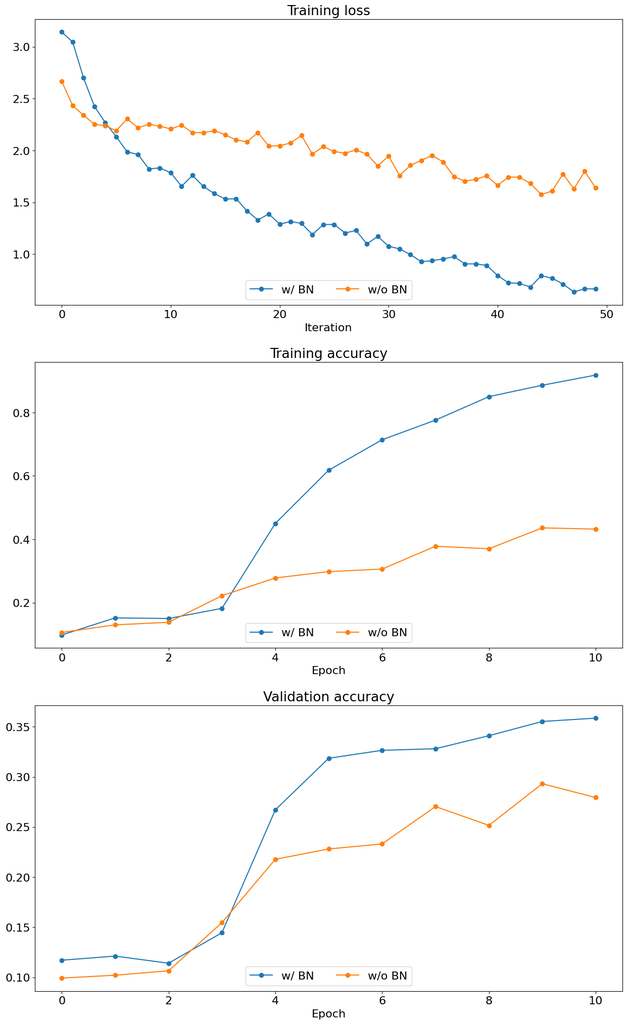

```python
def plot_training_history_bn(title, label, solvers, bn_solvers, plot_fn, bl_marker='.', bn_marker='.', labels=None):
  """utility function for plotting training history"""
  plt.title(title)
  plt.xlabel(label)
  bn_plots = [plot_fn(bn_solver) for bn_solver in bn_solvers]
  bl_plots = [plot_fn(solver) for solver in solvers]
  num_bn = len(bn_plots)
  num_bl = len(bl_plots)
  for i in range(num_bn):
    label='w/ BN'
    if labels is not None:
      label += str(labels[i])
    plt.plot(bn_plots[i], bn_marker, label=label)
  for i in range(num_bl):
    label='w/o BN'
    if labels is not None:
      label += str(labels[i])
    plt.plot(bl_plots[i], bl_marker, label=label)
  plt.legend(loc='lower center', ncol=num_bn+num_bl)

plt.subplot(3, 1, 1)
plot_training_history_bn('Training loss','Iteration', [solver], [bn_solver], \
                      lambda x: x.loss_history, bl_marker='-o', bn_marker='-o')
plt.subplot(3, 1, 2)
plot_training_history_bn('Training accuracy','Epoch', [solver], [bn_solver], \
                      lambda x: x.train_acc_history, bl_marker='-o', bn_marker='-o')
plt.subplot(3, 1, 3)
plot_training_history_bn('Validation accuracy','Epoch', [solver], [bn_solver], \
                      lambda x: x.val_acc_history, bl_marker='-o', bn_marker='-o')

plt.gcf().set_size_inches(15, 25)
plt.show()
```

# Batch normalization and learning rate (2 points)

We will now run a small experiment to study the interaction of batch normalization and learning rate.

The first cell will train convolutional networks with different learning rates. The second layer will plot training accuracy and validation set accuracy over time. You should find that using batch normalization helps the network to be less dependent to the learning rate. In other words, when not using batch normalization, there might be cases that certain learning rates might lead to very different performance (in terms of train/validation accuracy).

```python
from convolutional_networks import DeepConvNet
from fully_connected_networks import sgd_momentum
reset_seed(0)

# Try training a very deep net with batchnorm
num_train = 10000
small_data = {
  'X_train': data_dict['X_train'][:num_train],
  'y_train': data_dict['y_train'][:num_train],
  'X_val': data_dict['X_val'],
  'y_val': data_dict['y_val'],
}
input_dims = data_dict['X_train'].shape[1:]
num_epochs = 5
lrs = [2e-1, 1e-1, 5e-2]
lrs = [5e-3, 1e-2, 2e-2]

solvers = []
for lr in lrs:
  print('No normalization: learning rate = ', lr)
  model = DeepConvNet(input_dims=input_dims, num_classes=10,
                      num_filters=[8, 8, 8],
                      max_pools=[0, 1, 2],
                      weight_scale='kaiming',
                      batchnorm=False,
                      reg=1e-5, dtype=torch.float32, device='cuda')
  solver = Solver(model, small_data,
                  num_epochs=num_epochs, batch_size=100,
                  update_rule=sgd_momentum,
                  optim_config={
                    'learning_rate': lr,
                  },
                  verbose=False, device='cuda')
  solver.train()
  solvers.append(solver)

bn_solvers = []
for lr in lrs:
  print('Normalization: learning rate = ', lr)
  bn_model = DeepConvNet(input_dims=input_dims, num_classes=10,
                         num_filters=[8, 8, 16, 16, 32, 32],
                         max_pools=[1, 3, 5],
                         weight_scale='kaiming',
                         batchnorm=True,
                         reg=1e-5, dtype=torch.float32, device='cuda')
  bn_solver = Solver(bn_model, small_data,
                     num_epochs=num_epochs, batch_size=128,
                     update_rule=sgd_momentum,
                     optim_config={
                       'learning_rate': lr,
                     },
                     verbose=False, device='cuda')
  bn_solver.train()
  bn_solvers.append(bn_solver)
```

```
No normalization: learning rate =  0.005
No normalization: learning rate =  0.01
No normalization: learning rate =  0.02
Normalization: learning rate =  0.005
Normalization: learning rate =  0.01
Normalization: learning rate =  0.02
```

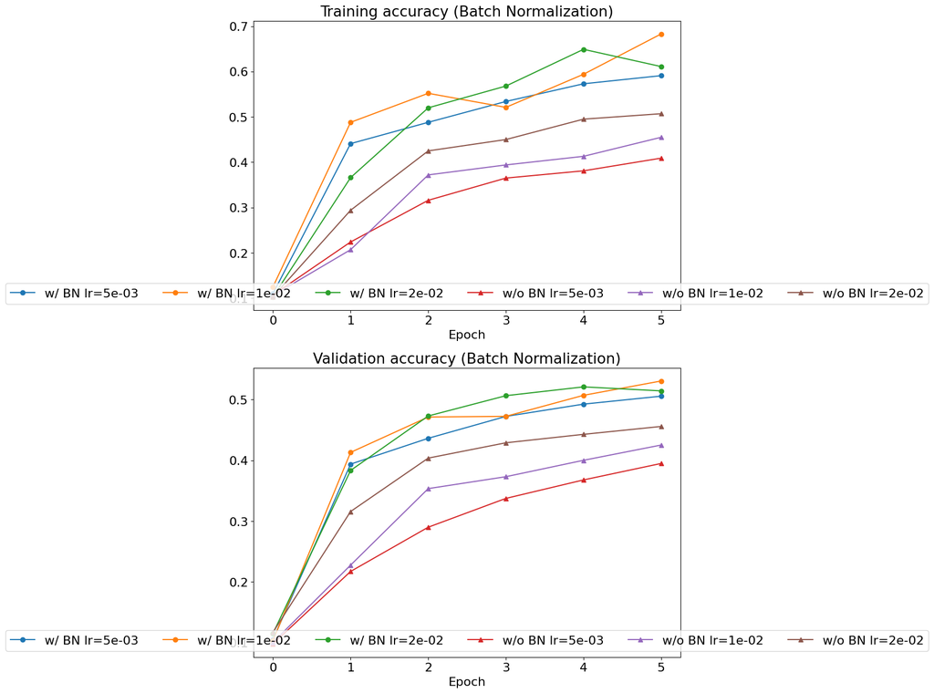

```python
plt.subplot(2, 1, 1)
plot_training_history_bn('Training accuracy (Batch Normalization)','Epoch', solvers, bn_solvers, \
                      lambda x: x.train_acc_history, bl_marker='-^', bn_marker='-o', labels=[' lr={:.0e}'.format(lr) for lr in lrs])
plt.subplot(2, 1, 2)
plot_training_history_bn('Validation accuracy (Batch Normalization)','Epoch', solvers, bn_solvers, \
                      lambda x: x.val_acc_history, bl_marker='-^', bn_marker='-o', labels=[' lr={:.0e}'.format(lr) for lr in lrs])

plt.gcf().set_size_inches(10, 15)
plt.show()
```

# Submit Your Work

After completing both notebooks for this assignment (`fully_connected_networks.ipynb` and this notebook, `convolutional_networks.ipynb`), run the following cell to create a `.zip` file for you to download and turn in.

**Please MANUALLY SAVE every `*.ipynb` and `*.py` files before executing the following cell:**

```python
from cs639.submit import make_ps2_submission

make_ps2_submission("./")
```

```
Writing zip file to:  ./jonathan_charlie_PS2.zip
```